# Predicting Company Bankruptcies

Predicting Company Bankruptcies

### Introduction

In today’s highly competitive and dynamic economic environment, companies face increasing financial pressure due to market volatility, rising operational costs, and uncertain economic conditions. As a result, corporate bankruptcy has become a significant concern for financial institutions, investors, and regulatory bodies. Early identification of financially distressed companies is essential to reduce financial risks and support informed decision-making.

This project focuses on developing a machine learning–based system to predict company bankruptcies using historical financial data and key financial ratios. By analyzing patterns related to profitability, liquidity, leverage, and cash flow, the proposed model aims to classify companies as bankrupt or non-bankrupt with high accuracy. The solution assists organizations in improving risk assessment, optimizing investment strategies, and enhancing overall financial stability through data-driven insights.

### Problem Statement

Corporate bankruptcy poses a major risk to financial institutions, investors, and stakeholders, as unexpected business failures can lead to significant financial losses and economic instability. Traditional methods of assessing bankruptcy risk often rely on manual analysis and fixed financial rules, which may fail to capture complex relationships among financial indicators and are unable to adapt to changing market conditions.

The objective of this project is to design and implement a robust machine learning–based classification system that accurately predicts whether a company is likely to go bankrupt based on its financial ratios. The model must handle class imbalance, select the most relevant financial features, and evaluate multiple machine learning algorithms to identify the most effective approach. By providing reliable bankruptcy predictions, the system aims to support data-driven risk assessment and informed financial decision-making.

### Problem Type

This is a binary classification problem where the objective is to predict whether a company will go bankrupt (1) or not bankrupt (0) based on financial ratios.

### Project Workflow

- Step 1 | Import Required Libraries
- Step 2 | Data Loading
- Step 3 | Dataset Overview & Understanding
- Step 4 | Target Variable Analysis
- Step 5 | Exploratory Data Analysis (EDA)
- Step 6 | Correlation Analysis & Insights
- Step 7 | Feature Selection
- Step 8 | Data Preprocessing
- Step 9 | Feature Scaling & Train-Test Split
- Step 10 | Logistic Regression Model
- Step 11 | Decision Tree Model
- Step 12 | Random Forest Model
- Step 13 | Gradient Boosting Model
- Step 14 | XGBoost Model (Optional)
- Step 15 | Model Evaluation, Comparison & Conclusion

## Let's get started:

# Import Libraries

### Step 1 | Import Required Libraries

```python
import numpy as np
import pandas as pd
import os

import matplotlib.pyplot as plt
import seaborn as sns
from matplotlib.colors import ListedColormap

from sklearn.model_selection import train_test_split
from scipy.stats import boxcox
from sklearn.pipeline import Pipeline
from sklearn.preprocessing import StandardScaler,OneHotEncoder
from sklearn.model_selection import GridSearchCV, StratifiedKFold

from sklearn.svm import SVC
from sklearn.tree import DecisionTreeClassifier
from sklearn.ensemble import RandomForestClassifier
from sklearn.linear_model import LogisticRegression
from sklearn.compose import ColumnTransformer
from sklearn.preprocessing import LabelEncoder

from sklearn.metrics import classification_report, accuracy_score, confusion_matrix

import ipywidgets as widgets
from IPython.display import display, HTML
import joblib
```

```python
os.getcwd()
```

```
'C:\\Users\\ajoyb'
```

```python
os.chdir(r"C:\BLA Capston Projects")
```

```python
os.getcwd()
```

```
'C:\\BLA Capston Projects'
```

# Read Dataset

```python
import pandas as pd
import numpy as np
import matplotlib.pyplot as plt
import seaborn as sns
from sklearn.preprocessing import StandardScaler
from sklearn.cluster import KMeans
from sklearn.model_selection import train_test_split
from sklearn.ensemble import RandomForestClassifier
from sklearn.metrics import accuracy_score, classification_report
```

```python
df=pd.read_csv("Predicting Company Bankruptcies.csv")
```

```python
df
```

|  | Bankrupt? | ROA(C) before interest and depreciation before interest | ROA(A) before interest and % after tax | ROA(B) before interest and depreciation after tax | Operating Gross Margin | Realized Sales Gross Margin | Operating Profit Rate | Pre-tax net Interest Rate | After-tax net Interest Rate | Non-industry income and expenditure/revenue | ... | Net Income to Total Assets | Total assets to GNP price | No-credit Interval | Gross Profit to Sales | Net Income to Stockholder's Equity | Liability to Equity | Degree of Financial Leverage (DFL) | Interest Coverage Ratio (Interest expense to EBIT) | Net Income Flag | Equity to Liability |
| --- | --- | --- | --- | --- | --- | --- | --- | --- | --- | --- | --- | --- | --- | --- | --- | --- | --- | --- | --- | --- | --- |
| 0 | 1 | 0.370594 | 0.424389 | 0.405750 | 0.601457 | 0.601457 | 0.998969 | 0.796887 | 0.808809 | 0.302646 | ... | 0.716845 | 0.009219 | 0.622879 | 0.601453 | 0.827890 | 0.290202 | 0.026601 | 0.564050 | 1 | 0.016469 |
| 1 | 1 | 0.464291 | 0.538214 | 0.516730 | 0.610235 | 0.610235 | 0.998946 | 0.797380 | 0.809301 | 0.303556 | ... | 0.795297 | 0.008323 | 0.623652 | 0.610237 | 0.839969 | 0.283846 | 0.264577 | 0.570175 | 1 | 0.020794 |
| 2 | 1 | 0.426071 | 0.499019 | 0.472295 | 0.601450 | 0.601364 | 0.998857 | 0.796403 | 0.808388 | 0.302035 | ... | 0.774670 | 0.040003 | 0.623841 | 0.601449 | 0.836774 | 0.290189 | 0.026555 | 0.563706 | 1 | 0.016474 |
| 3 | 1 | 0.399844 | 0.451265 | 0.457733 | 0.583541 | 0.583541 | 0.998700 | 0.796967 | 0.808966 | 0.303350 | ... | 0.739555 | 0.003252 | 0.622929 | 0.583538 | 0.834697 | 0.281721 | 0.026697 | 0.564663 | 1 | 0.023982 |
| 4 | 1 | 0.465022 | 0.538432 | 0.522298 | 0.598783 | 0.598783 | 0.998973 | 0.797366 | 0.809304 | 0.303475 | ... | 0.795016 | 0.003878 | 0.623521 | 0.598782 | 0.839973 | 0.278514 | 0.024752 | 0.575617 | 1 | 0.035490 |
| ... | ... | ... | ... | ... | ... | ... | ... | ... | ... | ... | ... | ... | ... | ... | ... | ... | ... | ... | ... | ... | ... |
| 6814 | 0 | 0.493687 | 0.539468 | 0.543230 | 0.604455 | 0.604462 | 0.998992 | 0.797409 | 0.809331 | 0.303510 | ... | 0.799927 | 0.000466 | 0.623620 | 0.604455 | 0.840359 | 0.279606 | 0.027064 | 0.566193 | 1 | 0.029890 |
| 6815 | 0 | 0.475162 | 0.538269 | 0.524172 | 0.598308 | 0.598308 | 0.998992 | 0.797414 | 0.809327 | 0.303520 | ... | 0.799748 | 0.001959 | 0.623931 | 0.598306 | 0.840306 | 0.278132 | 0.027009 | 0.566018 | 1 | 0.038284 |
| 6816 | 0 | 0.472725 | 0.533744 | 0.520638 | 0.610444 | 0.610213 | 0.998984 | 0.797401 | 0.809317 | 0.303512 | ... | 0.797778 | 0.002840 | 0.624156 | 0.610441 | 0.840138 | 0.275789 | 0.026791 | 0.565158 | 1 | 0.097649 |
| 6817 | 0 | 0.506264 | 0.559911 | 0.554045 | 0.607850 | 0.607850 | 0.999074 | 0.797500 | 0.809399 | 0.303498 | ... | 0.811808 | 0.002837 | 0.623957 | 0.607846 | 0.841084 | 0.277547 | 0.026822 | 0.565302 | 1 | 0.044009 |
| 6818 | 0 | 0.493053 | 0.570105 | 0.549548 | 0.627409 | 0.627409 | 0.998080 | 0.801987 | 0.813800 | 0.313415 | ... | 0.815956 | 0.000707 | 0.626680 | 0.627408 | 0.841019 | 0.275114 | 0.026793 | 0.565167 | 1 | 0.233902 |

6819 rows × 96 columns

## Dataset Description

### Data Summary & Description

The dataset used in this project contains financial information of companies and is designed to predict corporate bankruptcy. Each record represents a company described by multiple financial ratios related to profitability, liquidity, leverage, and operational efficiency. The dataset is used to analyze financial health and classify companies as bankrupt or non-bankrupt using machine learning techniques.

### Descriptive Statistics for Numerical Features

| Feature Category | Description |
| --- | --- |
| Profitability Ratios | Measure a company’s ability to generate profit relative to revenue, assets, or equity |
| Liquidity Ratios | Indicate a company’s ability to meet short-term financial obligations |
| Leverage Ratios | Reflect the extent of debt used in financing company assets |
| Cash Flow Indicators | Show the efficiency of cash generation from business operations |
| Operational Efficiency | Evaluate how effectively a company utilizes its resources |

### Variable Descriptions (Bankruptcy Dataset)

| Variable | Description |
| --- | --- |
| Financial Ratios | Multiple numerical features representing liquidity, profitability, leverage, and cash flow metrics of companies |
| Company Records | Each row corresponds to the financial profile of a single company |
| Total Features | 95 financial indicators used as input variables |
| Bankrupt? | Target Variable indicating company bankruptcy status 1 = Bankrupt Company 0 = Non-Bankrupt Company |

### Step 2 | Data Loading

## Data Loading

### Loading the Dataset

In this step, the bankruptcy prediction dataset is loaded into the Python environment using the Pandas library. The dataset is stored in a CSV file format and contains financial information of multiple companies. Proper data loading is essential to ensure that all features and target variables are correctly imported for further analysis.

### Description

After loading the dataset, it is ready for further steps such as exploratory data analysis, preprocessing, feature selection, and model training.

```python
df
```

|  | Bankrupt? | ROA(C) before interest and depreciation before interest | ROA(A) before interest and % after tax | ROA(B) before interest and depreciation after tax | Operating Gross Margin | Realized Sales Gross Margin | Operating Profit Rate | Pre-tax net Interest Rate | After-tax net Interest Rate | Non-industry income and expenditure/revenue | ... | Net Income to Total Assets | Total assets to GNP price | No-credit Interval | Gross Profit to Sales | Net Income to Stockholder's Equity | Liability to Equity | Degree of Financial Leverage (DFL) | Interest Coverage Ratio (Interest expense to EBIT) | Net Income Flag | Equity to Liability |
| --- | --- | --- | --- | --- | --- | --- | --- | --- | --- | --- | --- | --- | --- | --- | --- | --- | --- | --- | --- | --- | --- |
| 0 | 1 | 0.370594 | 0.424389 | 0.405750 | 0.601457 | 0.601457 | 0.998969 | 0.796887 | 0.808809 | 0.302646 | ... | 0.716845 | 0.009219 | 0.622879 | 0.601453 | 0.827890 | 0.290202 | 0.026601 | 0.564050 | 1 | 0.016469 |
| 1 | 1 | 0.464291 | 0.538214 | 0.516730 | 0.610235 | 0.610235 | 0.998946 | 0.797380 | 0.809301 | 0.303556 | ... | 0.795297 | 0.008323 | 0.623652 | 0.610237 | 0.839969 | 0.283846 | 0.264577 | 0.570175 | 1 | 0.020794 |
| 2 | 1 | 0.426071 | 0.499019 | 0.472295 | 0.601450 | 0.601364 | 0.998857 | 0.796403 | 0.808388 | 0.302035 | ... | 0.774670 | 0.040003 | 0.623841 | 0.601449 | 0.836774 | 0.290189 | 0.026555 | 0.563706 | 1 | 0.016474 |
| 3 | 1 | 0.399844 | 0.451265 | 0.457733 | 0.583541 | 0.583541 | 0.998700 | 0.796967 | 0.808966 | 0.303350 | ... | 0.739555 | 0.003252 | 0.622929 | 0.583538 | 0.834697 | 0.281721 | 0.026697 | 0.564663 | 1 | 0.023982 |
| 4 | 1 | 0.465022 | 0.538432 | 0.522298 | 0.598783 | 0.598783 | 0.998973 | 0.797366 | 0.809304 | 0.303475 | ... | 0.795016 | 0.003878 | 0.623521 | 0.598782 | 0.839973 | 0.278514 | 0.024752 | 0.575617 | 1 | 0.035490 |
| ... | ... | ... | ... | ... | ... | ... | ... | ... | ... | ... | ... | ... | ... | ... | ... | ... | ... | ... | ... | ... | ... |
| 6814 | 0 | 0.493687 | 0.539468 | 0.543230 | 0.604455 | 0.604462 | 0.998992 | 0.797409 | 0.809331 | 0.303510 | ... | 0.799927 | 0.000466 | 0.623620 | 0.604455 | 0.840359 | 0.279606 | 0.027064 | 0.566193 | 1 | 0.029890 |
| 6815 | 0 | 0.475162 | 0.538269 | 0.524172 | 0.598308 | 0.598308 | 0.998992 | 0.797414 | 0.809327 | 0.303520 | ... | 0.799748 | 0.001959 | 0.623931 | 0.598306 | 0.840306 | 0.278132 | 0.027009 | 0.566018 | 1 | 0.038284 |
| 6816 | 0 | 0.472725 | 0.533744 | 0.520638 | 0.610444 | 0.610213 | 0.998984 | 0.797401 | 0.809317 | 0.303512 | ... | 0.797778 | 0.002840 | 0.624156 | 0.610441 | 0.840138 | 0.275789 | 0.026791 | 0.565158 | 1 | 0.097649 |
| 6817 | 0 | 0.506264 | 0.559911 | 0.554045 | 0.607850 | 0.607850 | 0.999074 | 0.797500 | 0.809399 | 0.303498 | ... | 0.811808 | 0.002837 | 0.623957 | 0.607846 | 0.841084 | 0.277547 | 0.026822 | 0.565302 | 1 | 0.044009 |
| 6818 | 0 | 0.493053 | 0.570105 | 0.549548 | 0.627409 | 0.627409 | 0.998080 | 0.801987 | 0.813800 | 0.313415 | ... | 0.815956 | 0.000707 | 0.626680 | 0.627408 | 0.841019 | 0.275114 | 0.026793 | 0.565167 | 1 | 0.233902 |

6819 rows × 96 columns

```python
df.head()
```

|  | Bankrupt? | ROA(C) before interest and depreciation before interest | ROA(A) before interest and % after tax | ROA(B) before interest and depreciation after tax | Operating Gross Margin | Realized Sales Gross Margin | Operating Profit Rate | Pre-tax net Interest Rate | After-tax net Interest Rate | Non-industry income and expenditure/revenue | ... | Net Income to Total Assets | Total assets to GNP price | No-credit Interval | Gross Profit to Sales | Net Income to Stockholder's Equity | Liability to Equity | Degree of Financial Leverage (DFL) | Interest Coverage Ratio (Interest expense to EBIT) | Net Income Flag | Equity to Liability |
| --- | --- | --- | --- | --- | --- | --- | --- | --- | --- | --- | --- | --- | --- | --- | --- | --- | --- | --- | --- | --- | --- |
| 0 | 1 | 0.370594 | 0.424389 | 0.405750 | 0.601457 | 0.601457 | 0.998969 | 0.796887 | 0.808809 | 0.302646 | ... | 0.716845 | 0.009219 | 0.622879 | 0.601453 | 0.827890 | 0.290202 | 0.026601 | 0.564050 | 1 | 0.016469 |
| 1 | 1 | 0.464291 | 0.538214 | 0.516730 | 0.610235 | 0.610235 | 0.998946 | 0.797380 | 0.809301 | 0.303556 | ... | 0.795297 | 0.008323 | 0.623652 | 0.610237 | 0.839969 | 0.283846 | 0.264577 | 0.570175 | 1 | 0.020794 |
| 2 | 1 | 0.426071 | 0.499019 | 0.472295 | 0.601450 | 0.601364 | 0.998857 | 0.796403 | 0.808388 | 0.302035 | ... | 0.774670 | 0.040003 | 0.623841 | 0.601449 | 0.836774 | 0.290189 | 0.026555 | 0.563706 | 1 | 0.016474 |
| 3 | 1 | 0.399844 | 0.451265 | 0.457733 | 0.583541 | 0.583541 | 0.998700 | 0.796967 | 0.808966 | 0.303350 | ... | 0.739555 | 0.003252 | 0.622929 | 0.583538 | 0.834697 | 0.281721 | 0.026697 | 0.564663 | 1 | 0.023982 |
| 4 | 1 | 0.465022 | 0.538432 | 0.522298 | 0.598783 | 0.598783 | 0.998973 | 0.797366 | 0.809304 | 0.303475 | ... | 0.795016 | 0.003878 | 0.623521 | 0.598782 | 0.839973 | 0.278514 | 0.024752 | 0.575617 | 1 | 0.035490 |

5 rows × 96 columns

```python
df.shape
```

```
(6819, 96)
```

```python
df.columns
```

```
Index(['Bankrupt?', ' ROA(C) before interest and depreciation before interest',
       ' ROA(A) before interest and % after tax',
       ' ROA(B) before interest and depreciation after tax',
       ' Operating Gross Margin', ' Realized Sales Gross Margin',
       ' Operating Profit Rate', ' Pre-tax net Interest Rate',
       ' After-tax net Interest Rate',
       ' Non-industry income and expenditure/revenue',
       ' Continuous interest rate (after tax)', ' Operating Expense Rate',
       ' Research and development expense rate', ' Cash flow rate',
       ' Interest-bearing debt interest rate', ' Tax rate (A)',
       ' Net Value Per Share (B)', ' Net Value Per Share (A)',
       ' Net Value Per Share (C)', ' Persistent EPS in the Last Four Seasons',
       ' Cash Flow Per Share', ' Revenue Per Share (Yuan ¥)',
       ' Operating Profit Per Share (Yuan ¥)',
       ' Per Share Net profit before tax (Yuan ¥)',
       ' Realized Sales Gross Profit Growth Rate',
       ' Operating Profit Growth Rate', ' After-tax Net Profit Growth Rate',
       ' Regular Net Profit Growth Rate', ' Continuous Net Profit Growth Rate',
       ' Total Asset Growth Rate', ' Net Value Growth Rate',
       ' Total Asset Return Growth Rate Ratio', ' Cash Reinvestment %',
       ' Current Ratio', ' Quick Ratio', ' Interest Expense Ratio',
       ' Total debt/Total net worth', ' Debt ratio %', ' Net worth/Assets',
       ' Long-term fund suitability ratio (A)', ' Borrowing dependency',
       ' Contingent liabilities/Net worth',
       ' Operating profit/Paid-in capital',
       ' Net profit before tax/Paid-in capital',
       ' Inventory and accounts receivable/Net value', ' Total Asset Turnover',
       ' Accounts Receivable Turnover', ' Average Collection Days',
       ' Inventory Turnover Rate (times)', ' Fixed Assets Turnover Frequency',
       ' Net Worth Turnover Rate (times)', ' Revenue per person',
       ' Operating profit per person', ' Allocation rate per person',
       ' Working Capital to Total Assets', ' Quick Assets/Total Assets',
       ' Current Assets/Total Assets', ' Cash/Total Assets',
       ' Quick Assets/Current Liability', ' Cash/Current Liability',
       ' Current Liability to Assets', ' Operating Funds to Liability',
       ' Inventory/Working Capital', ' Inventory/Current Liability',
       ' Current Liabilities/Liability', ' Working Capital/Equity',
       ' Current Liabilities/Equity', ' Long-term Liability to Current Assets',
       ' Retained Earnings to Total Assets', ' Total income/Total expense',
       ' Total expense/Assets', ' Current Asset Turnover Rate',
       ' Quick Asset Turnover Rate', ' Working capitcal Turnover Rate',
       ' Cash Turnover Rate', ' Cash Flow to Sales', ' Fixed Assets to Assets',
       ' Current Liability to Liability', ' Current Liability to Equity',
       ' Equity to Long-term Liability', ' Cash Flow to Total Assets',
       ' Cash Flow to Liability', ' CFO to Assets', ' Cash Flow to Equity',
       ' Current Liability to Current Assets', ' Liability-Assets Flag',
       ' Net Income to Total Assets', ' Total assets to GNP price',
       ' No-credit Interval', ' Gross Profit to Sales',
       ' Net Income to Stockholder's Equity', ' Liability to Equity',
       ' Degree of Financial Leverage (DFL)',
       ' Interest Coverage Ratio (Interest expense to EBIT)',
       ' Net Income Flag', ' Equity to Liability'],
      dtype='object')
```

```python
df['Bankrupt?'].value_counts()
```

```
Bankrupt?
0    6599
1     220
Name: count, dtype: int64
```

### Step 3 | Dataset Overview & Understanding

```python
df.shape
```

```
(6819, 96)
```

```python
df.columns
```

```
Index(['Bankrupt?', ' ROA(C) before interest and depreciation before interest',
       ' ROA(A) before interest and % after tax',
       ' ROA(B) before interest and depreciation after tax',
       ' Operating Gross Margin', ' Realized Sales Gross Margin',
       ' Operating Profit Rate', ' Pre-tax net Interest Rate',
       ' After-tax net Interest Rate',
       ' Non-industry income and expenditure/revenue',
       ' Continuous interest rate (after tax)', ' Operating Expense Rate',
       ' Research and development expense rate', ' Cash flow rate',
       ' Interest-bearing debt interest rate', ' Tax rate (A)',
       ' Net Value Per Share (B)', ' Net Value Per Share (A)',
       ' Net Value Per Share (C)', ' Persistent EPS in the Last Four Seasons',
       ' Cash Flow Per Share', ' Revenue Per Share (Yuan ¥)',
       ' Operating Profit Per Share (Yuan ¥)',
       ' Per Share Net profit before tax (Yuan ¥)',
       ' Realized Sales Gross Profit Growth Rate',
       ' Operating Profit Growth Rate', ' After-tax Net Profit Growth Rate',
       ' Regular Net Profit Growth Rate', ' Continuous Net Profit Growth Rate',
       ' Total Asset Growth Rate', ' Net Value Growth Rate',
       ' Total Asset Return Growth Rate Ratio', ' Cash Reinvestment %',
       ' Current Ratio', ' Quick Ratio', ' Interest Expense Ratio',
       ' Total debt/Total net worth', ' Debt ratio %', ' Net worth/Assets',
       ' Long-term fund suitability ratio (A)', ' Borrowing dependency',
       ' Contingent liabilities/Net worth',
       ' Operating profit/Paid-in capital',
       ' Net profit before tax/Paid-in capital',
       ' Inventory and accounts receivable/Net value', ' Total Asset Turnover',
       ' Accounts Receivable Turnover', ' Average Collection Days',
       ' Inventory Turnover Rate (times)', ' Fixed Assets Turnover Frequency',
       ' Net Worth Turnover Rate (times)', ' Revenue per person',
       ' Operating profit per person', ' Allocation rate per person',
       ' Working Capital to Total Assets', ' Quick Assets/Total Assets',
       ' Current Assets/Total Assets', ' Cash/Total Assets',
       ' Quick Assets/Current Liability', ' Cash/Current Liability',
       ' Current Liability to Assets', ' Operating Funds to Liability',
       ' Inventory/Working Capital', ' Inventory/Current Liability',
       ' Current Liabilities/Liability', ' Working Capital/Equity',
       ' Current Liabilities/Equity', ' Long-term Liability to Current Assets',
       ' Retained Earnings to Total Assets', ' Total income/Total expense',
       ' Total expense/Assets', ' Current Asset Turnover Rate',
       ' Quick Asset Turnover Rate', ' Working capitcal Turnover Rate',
       ' Cash Turnover Rate', ' Cash Flow to Sales', ' Fixed Assets to Assets',
       ' Current Liability to Liability', ' Current Liability to Equity',
       ' Equity to Long-term Liability', ' Cash Flow to Total Assets',
       ' Cash Flow to Liability', ' CFO to Assets', ' Cash Flow to Equity',
       ' Current Liability to Current Assets', ' Liability-Assets Flag',
       ' Net Income to Total Assets', ' Total assets to GNP price',
       ' No-credit Interval', ' Gross Profit to Sales',
       ' Net Income to Stockholder's Equity', ' Liability to Equity',
       ' Degree of Financial Leverage (DFL)',
       ' Interest Coverage Ratio (Interest expense to EBIT)',
       ' Net Income Flag', ' Equity to Liability'],
      dtype='object')
```

```python
df.info()
```

```
<class 'pandas.core.frame.DataFrame'>
RangeIndex: 6819 entries, 0 to 6818
Data columns (total 96 columns):
 #   Column                                                    Non-Null Count  Dtype
---  ------                                                    --------------  -----
 0   Bankrupt?                                                 6819 non-null   int64
 1    ROA(C) before interest and depreciation before interest  6819 non-null   float64
 2    ROA(A) before interest and % after tax                   6819 non-null   float64
 3    ROA(B) before interest and depreciation after tax        6819 non-null   float64
 4    Operating Gross Margin                                   6819 non-null   float64
 5    Realized Sales Gross Margin                              6819 non-null   float64
 6    Operating Profit Rate                                    6819 non-null   float64
 7    Pre-tax net Interest Rate                                6819 non-null   float64
 8    After-tax net Interest Rate                              6819 non-null   float64
 9    Non-industry income and expenditure/revenue              6819 non-null   float64
```

[output cut: 88 more lines]

```python
df.head()
```

|  | Bankrupt? | ROA(C) before interest and depreciation before interest | ROA(A) before interest and % after tax | ROA(B) before interest and depreciation after tax | Operating Gross Margin | Realized Sales Gross Margin | Operating Profit Rate | Pre-tax net Interest Rate | After-tax net Interest Rate | Non-industry income and expenditure/revenue | ... | Net Income to Total Assets | Total assets to GNP price | No-credit Interval | Gross Profit to Sales | Net Income to Stockholder's Equity | Liability to Equity | Degree of Financial Leverage (DFL) | Interest Coverage Ratio (Interest expense to EBIT) | Net Income Flag | Equity to Liability |
| --- | --- | --- | --- | --- | --- | --- | --- | --- | --- | --- | --- | --- | --- | --- | --- | --- | --- | --- | --- | --- | --- |
| 0 | 1 | 0.370594 | 0.424389 | 0.405750 | 0.601457 | 0.601457 | 0.998969 | 0.796887 | 0.808809 | 0.302646 | ... | 0.716845 | 0.009219 | 0.622879 | 0.601453 | 0.827890 | 0.290202 | 0.026601 | 0.564050 | 1 | 0.016469 |
| 1 | 1 | 0.464291 | 0.538214 | 0.516730 | 0.610235 | 0.610235 | 0.998946 | 0.797380 | 0.809301 | 0.303556 | ... | 0.795297 | 0.008323 | 0.623652 | 0.610237 | 0.839969 | 0.283846 | 0.264577 | 0.570175 | 1 | 0.020794 |
| 2 | 1 | 0.426071 | 0.499019 | 0.472295 | 0.601450 | 0.601364 | 0.998857 | 0.796403 | 0.808388 | 0.302035 | ... | 0.774670 | 0.040003 | 0.623841 | 0.601449 | 0.836774 | 0.290189 | 0.026555 | 0.563706 | 1 | 0.016474 |
| 3 | 1 | 0.399844 | 0.451265 | 0.457733 | 0.583541 | 0.583541 | 0.998700 | 0.796967 | 0.808966 | 0.303350 | ... | 0.739555 | 0.003252 | 0.622929 | 0.583538 | 0.834697 | 0.281721 | 0.026697 | 0.564663 | 1 | 0.023982 |
| 4 | 1 | 0.465022 | 0.538432 | 0.522298 | 0.598783 | 0.598783 | 0.998973 | 0.797366 | 0.809304 | 0.303475 | ... | 0.795016 | 0.003878 | 0.623521 | 0.598782 | 0.839973 | 0.278514 | 0.024752 | 0.575617 | 1 | 0.035490 |

5 rows × 96 columns

```python
df.tail()
```

|  | Bankrupt? | ROA(C) before interest and depreciation before interest | ROA(A) before interest and % after tax | ROA(B) before interest and depreciation after tax | Operating Gross Margin | Realized Sales Gross Margin | Operating Profit Rate | Pre-tax net Interest Rate | After-tax net Interest Rate | Non-industry income and expenditure/revenue | ... | Net Income to Total Assets | Total assets to GNP price | No-credit Interval | Gross Profit to Sales | Net Income to Stockholder's Equity | Liability to Equity | Degree of Financial Leverage (DFL) | Interest Coverage Ratio (Interest expense to EBIT) | Net Income Flag | Equity to Liability |
| --- | --- | --- | --- | --- | --- | --- | --- | --- | --- | --- | --- | --- | --- | --- | --- | --- | --- | --- | --- | --- | --- |
| 6814 | 0 | 0.493687 | 0.539468 | 0.543230 | 0.604455 | 0.604462 | 0.998992 | 0.797409 | 0.809331 | 0.303510 | ... | 0.799927 | 0.000466 | 0.623620 | 0.604455 | 0.840359 | 0.279606 | 0.027064 | 0.566193 | 1 | 0.029890 |
| 6815 | 0 | 0.475162 | 0.538269 | 0.524172 | 0.598308 | 0.598308 | 0.998992 | 0.797414 | 0.809327 | 0.303520 | ... | 0.799748 | 0.001959 | 0.623931 | 0.598306 | 0.840306 | 0.278132 | 0.027009 | 0.566018 | 1 | 0.038284 |
| 6816 | 0 | 0.472725 | 0.533744 | 0.520638 | 0.610444 | 0.610213 | 0.998984 | 0.797401 | 0.809317 | 0.303512 | ... | 0.797778 | 0.002840 | 0.624156 | 0.610441 | 0.840138 | 0.275789 | 0.026791 | 0.565158 | 1 | 0.097649 |
| 6817 | 0 | 0.506264 | 0.559911 | 0.554045 | 0.607850 | 0.607850 | 0.999074 | 0.797500 | 0.809399 | 0.303498 | ... | 0.811808 | 0.002837 | 0.623957 | 0.607846 | 0.841084 | 0.277547 | 0.026822 | 0.565302 | 1 | 0.044009 |
| 6818 | 0 | 0.493053 | 0.570105 | 0.549548 | 0.627409 | 0.627409 | 0.998080 | 0.801987 | 0.813800 | 0.313415 | ... | 0.815956 | 0.000707 | 0.626680 | 0.627408 | 0.841019 | 0.275114 | 0.026793 | 0.565167 | 1 | 0.233902 |

5 rows × 96 columns

```python
df.isnull().sum()
```

```
Bankrupt?                                                   0
 ROA(C) before interest and depreciation before interest    0
 ROA(A) before interest and % after tax                     0
 ROA(B) before interest and depreciation after tax          0
 Operating Gross Margin                                     0
                                                           ..
 Liability to Equity                                        0
 Degree of Financial Leverage (DFL)                         0
 Interest Coverage Ratio (Interest expense to EBIT)         0
 Net Income Flag                                            0
 Equity to Liability                                        0
Length: 96, dtype: int64
```

```python
df.describe()
```

|  | Bankrupt? | ROA(C) before interest and depreciation before interest | ROA(A) before interest and % after tax | ROA(B) before interest and depreciation after tax | Operating Gross Margin | Realized Sales Gross Margin | Operating Profit Rate | Pre-tax net Interest Rate | After-tax net Interest Rate | Non-industry income and expenditure/revenue | ... | Net Income to Total Assets | Total assets to GNP price | No-credit Interval | Gross Profit to Sales | Net Income to Stockholder's Equity | Liability to Equity | Degree of Financial Leverage (DFL) | Interest Coverage Ratio (Interest expense to EBIT) | Net Income Flag | Equity to Liability |
| --- | --- | --- | --- | --- | --- | --- | --- | --- | --- | --- | --- | --- | --- | --- | --- | --- | --- | --- | --- | --- | --- |
| count | 6819.000000 | 6819.000000 | 6819.000000 | 6819.000000 | 6819.000000 | 6819.000000 | 6819.000000 | 6819.000000 | 6819.000000 | 6819.000000 | ... | 6819.000000 | 6.819000e+03 | 6819.000000 | 6819.000000 | 6819.000000 | 6819.000000 | 6819.000000 | 6819.000000 | 6819.0 | 6819.000000 |
| mean | 0.032263 | 0.505180 | 0.558625 | 0.553589 | 0.607948 | 0.607929 | 0.998755 | 0.797190 | 0.809084 | 0.303623 | ... | 0.807760 | 1.862942e+07 | 0.623915 | 0.607946 | 0.840402 | 0.280365 | 0.027541 | 0.565358 | 1.0 | 0.047578 |
| std | 0.176710 | 0.060686 | 0.065620 | 0.061595 | 0.016934 | 0.016916 | 0.013010 | 0.012869 | 0.013601 | 0.011163 | ... | 0.040332 | 3.764501e+08 | 0.012290 | 0.016934 | 0.014523 | 0.014463 | 0.015668 | 0.013214 | 0.0 | 0.050014 |
| min | 0.000000 | 0.000000 | 0.000000 | 0.000000 | 0.000000 | 0.000000 | 0.000000 | 0.000000 | 0.000000 | 0.000000 | ... | 0.000000 | 0.000000e+00 | 0.000000 | 0.000000 | 0.000000 | 0.000000 | 0.000000 | 0.000000 | 1.0 | 0.000000 |
| 25% | 0.000000 | 0.476527 | 0.535543 | 0.527277 | 0.600445 | 0.600434 | 0.998969 | 0.797386 | 0.809312 | 0.303466 | ... | 0.796750 | 9.036205e-04 | 0.623636 | 0.600443 | 0.840115 | 0.276944 | 0.026791 | 0.565158 | 1.0 | 0.024477 |
| 50% | 0.000000 | 0.502706 | 0.559802 | 0.552278 | 0.605997 | 0.605976 | 0.999022 | 0.797464 | 0.809375 | 0.303525 | ... | 0.810619 | 2.085213e-03 | 0.623879 | 0.605998 | 0.841179 | 0.278778 | 0.026808 | 0.565252 | 1.0 | 0.033798 |
| 75% | 0.000000 | 0.535563 | 0.589157 | 0.584105 | 0.613914 | 0.613842 | 0.999095 | 0.797579 | 0.809469 | 0.303585 | ... | 0.826455 | 5.269777e-03 | 0.624168 | 0.613913 | 0.842357 | 0.281449 | 0.026913 | 0.565725 | 1.0 | 0.052838 |
| max | 1.000000 | 1.000000 | 1.000000 | 1.000000 | 1.000000 | 1.000000 | 1.000000 | 1.000000 | 1.000000 | 1.000000 | ... | 1.000000 | 9.820000e+09 | 1.000000 | 1.000000 | 1.000000 | 1.000000 | 1.000000 | 1.000000 | 1.0 | 1.000000 |

8 rows × 96 columns

```python
df['Bankrupt?'].value_counts()
```

```
Bankrupt?
0    6599
1     220
Name: count, dtype: int64
```

```python
df['Bankrupt?'].value_counts(normalize=True) * 100
```

```
Bankrupt?
0    96.77372
1     3.22628
Name: proportion, dtype: float64
```

```python
df['Bankrupt?'].value_counts()[0] / df['Bankrupt?'].value_counts()[1]
```

```
np.float64(29.995454545454546)
```

```python
print("Total Records:", df.shape[0])
print("Total Features:", df.shape[1])
print("\nTarget Variable Distribution:")
print(df['Bankrupt?'].value_counts())
```

```
Total Records: 6819
Total Features: 96

Target Variable Distribution:
Bankrupt?
0    6599
1     220
Name: count, dtype: int64
```

### Step 4 | Target Varible Analysis

```python
target = 'Bankrupt?'
target in df.columns
```

```
True
```

```python
df[target].value_counts()
```

```
Bankrupt?
0    6599
1     220
Name: count, dtype: int64
```

```python
df[target].value_counts(normalize=True) * 100
```

```
Bankrupt?
0    96.77372
1     3.22628
Name: proportion, dtype: float64
```

```python
non_bankrupt = df[target].value_counts()[0]
bankrupt = df[target].value_counts()[1]

imbalance_ratio = non_bankrupt / bankrupt
imbalance_ratio
```

```
np.float64(29.995454545454546)
```

```python
print("Non-Bankrupt Companies:", non_bankrupt)
print("Bankrupt Companies:", bankrupt)
print("Imbalance Ratio (Non-Bankrupt : Bankrupt):", round(imbalance_ratio, 2))
```

```
Non-Bankrupt Companies: 6599
Bankrupt Companies: 220
Imbalance Ratio (Non-Bankrupt : Bankrupt): 30.0
```

```python
df[target].unique()
```

```
array([1, 0])
```

```python
df[target].dtype
```

```
dtype('int64')
```

```python
if imbalance_ratio > 1:
    print("The dataset is imbalanced, with significantly fewer bankrupt companies.")
else:
    print("The dataset is balanced.")
```

```
The dataset is imbalanced, with significantly fewer bankrupt companies.
```

## Target Variable Analysis

The target variable `Bankrupt?` is a binary classification variable, where 1 represents bankrupt companies and 0 represents non-bankrupt companies. The analysis shows a significant class imbalance, with far fewer bankrupt cases compared to non-bankrupt cases. This imbalance reflects real-world financial scenarios and highlights the need for appropriate preprocessing techniques during model training.

### Class Imbalance Handling

The target variable shows a strong class imbalance, with significantly fewer bankrupt companies compared to non-bankrupt companies. This reflects real-world scenarios. Therefore, evaluation metrics such as Precision, Recall, and F1-score were prioritized over accuracy for model evaluation and comparison.

### Step 5 | Exploratory Data Analysis (EDA)

```python
import matplotlib.pyplot as plt
import seaborn as sns
import numpy as np
```

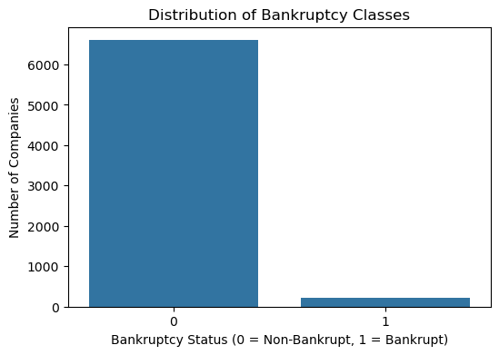

```python
plt.figure(figsize=(6,4))
sns.countplot(x='Bankrupt?', data=df)
plt.title("Distribution of Bankruptcy Classes")
plt.xlabel("Bankruptcy Status (0 = Non-Bankrupt, 1 = Bankrupt)")
plt.ylabel("Number of Companies")
plt.show()
```

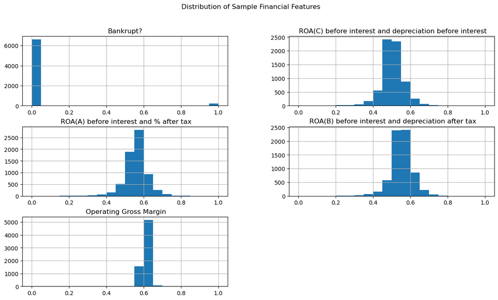

```python
df.iloc[:, :5].hist(figsize=(15,8), bins=20)
plt.suptitle("Distribution of Sample Financial Features")
plt.show()
```

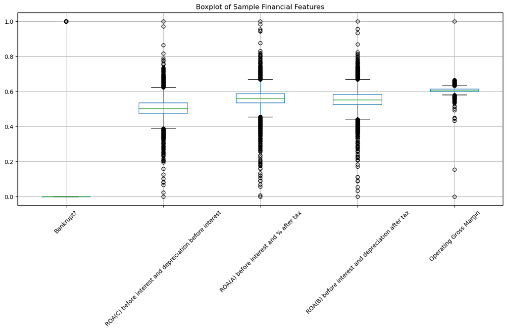

```python
plt.figure(figsize=(15,6))
df.iloc[:, :5].boxplot()
plt.title("Boxplot of Sample Financial Features")
plt.xticks(rotation=45)
plt.show()
```

```python
df.groupby('Bankrupt?').mean().head()
```

| Bankrupt? | ROA(C) before interest and depreciation before interest | ROA(A) before interest and % after tax | ROA(B) before interest and depreciation after tax | Operating Gross Margin | Realized Sales Gross Margin | Operating Profit Rate | Pre-tax net Interest Rate | After-tax net Interest Rate | Non-industry income and expenditure/revenue | Continuous interest rate (after tax) | ... | Net Income to Total Assets | Total assets to GNP price | No-credit Interval | Gross Profit to Sales | Net Income to Stockholder's Equity | Liability to Equity | Degree of Financial Leverage (DFL) | Interest Coverage Ratio (Interest expense to EBIT) | Net Income Flag | Equity to Liability |
| --- | --- | --- | --- | --- | --- | --- | --- | --- | --- | --- | --- | --- | --- | --- | --- | --- | --- | --- | --- | --- | --- |
| 0 | 0.508069 | 0.562015 | 0.556659 | 0.608257 | 0.608237 | 0.998756 | 0.79721 | 0.809106 | 0.303657 | 0.781401 | ... | 0.810083 | 1.621670e+07 | 0.623927 | 0.608256 | 0.840882 | 0.279925 | 0.027511 | 0.565371 | 1.0 | 0.048337 |
| 1 | 0.418503 | 0.456947 | 0.461483 | 0.598670 | 0.598717 | 0.998739 | 0.79659 | 0.808424 | 0.302609 | 0.780799 | ... | 0.738083 | 9.100000e+07 | 0.623541 | 0.598669 | 0.826008 | 0.293578 | 0.028443 | 0.564959 | 1.0 | 0.024832 |

2 rows × 95 columns

```python
correlation_matrix = df.corr()
correlation_matrix.head()
```

|  | Bankrupt? | ROA(C) before interest and depreciation before interest | ROA(A) before interest and % after tax | ROA(B) before interest and depreciation after tax | Operating Gross Margin | Realized Sales Gross Margin | Operating Profit Rate | Pre-tax net Interest Rate | After-tax net Interest Rate | Non-industry income and expenditure/revenue | ... | Net Income to Total Assets | Total assets to GNP price | No-credit Interval | Gross Profit to Sales | Net Income to Stockholder's Equity | Liability to Equity | Degree of Financial Leverage (DFL) | Interest Coverage Ratio (Interest expense to EBIT) | Net Income Flag | Equity to Liability |
| --- | --- | --- | --- | --- | --- | --- | --- | --- | --- | --- | --- | --- | --- | --- | --- | --- | --- | --- | --- | --- | --- |
| Bankrupt? | 1.000000 | -0.260807 | -0.282941 | -0.273051 | -0.100043 | -0.099445 | -0.000230 | -0.008517 | -0.008857 | -0.016593 | ... | -0.315457 | 0.035104 | -0.005547 | -0.100044 | -0.180987 | 0.166812 | 0.010508 | -0.005509 | NaN | -0.083048 |
| ROA(C) before interest and depreciation before interest | -0.260807 | 1.000000 | 0.940124 | 0.986849 | 0.334719 | 0.332755 | 0.035725 | 0.053419 | 0.049222 | 0.020501 | ... | 0.887670 | -0.071725 | 0.008135 | 0.334721 | 0.274287 | -0.143629 | -0.016575 | 0.010573 | NaN | 0.052416 |
| ROA(A) before interest and % after tax | -0.282941 | 0.940124 | 1.000000 | 0.955741 | 0.326969 | 0.324956 | 0.032053 | 0.053518 | 0.049474 | 0.029649 | ... | 0.961552 | -0.098900 | 0.011463 | 0.326971 | 0.291744 | -0.141039 | -0.011515 | 0.013372 | NaN | 0.057887 |
| ROA(B) before interest and depreciation after tax | -0.273051 | 0.986849 | 0.955741 | 1.000000 | 0.333749 | 0.331755 | 0.035212 | 0.053726 | 0.049952 | 0.022366 | ... | 0.912040 | -0.089088 | 0.007523 | 0.333750 | 0.280617 | -0.142838 | -0.014663 | 0.011473 | NaN | 0.056430 |
| Operating Gross Margin | -0.100043 | 0.334719 | 0.326969 | 0.333749 | 1.000000 | 0.999518 | 0.005745 | 0.032493 | 0.027175 | 0.051438 | ... | 0.300143 | 0.022672 | 0.004205 | 1.000000 | 0.075304 | -0.085434 | -0.011806 | -0.001167 | NaN | 0.120029 |

5 rows × 96 columns

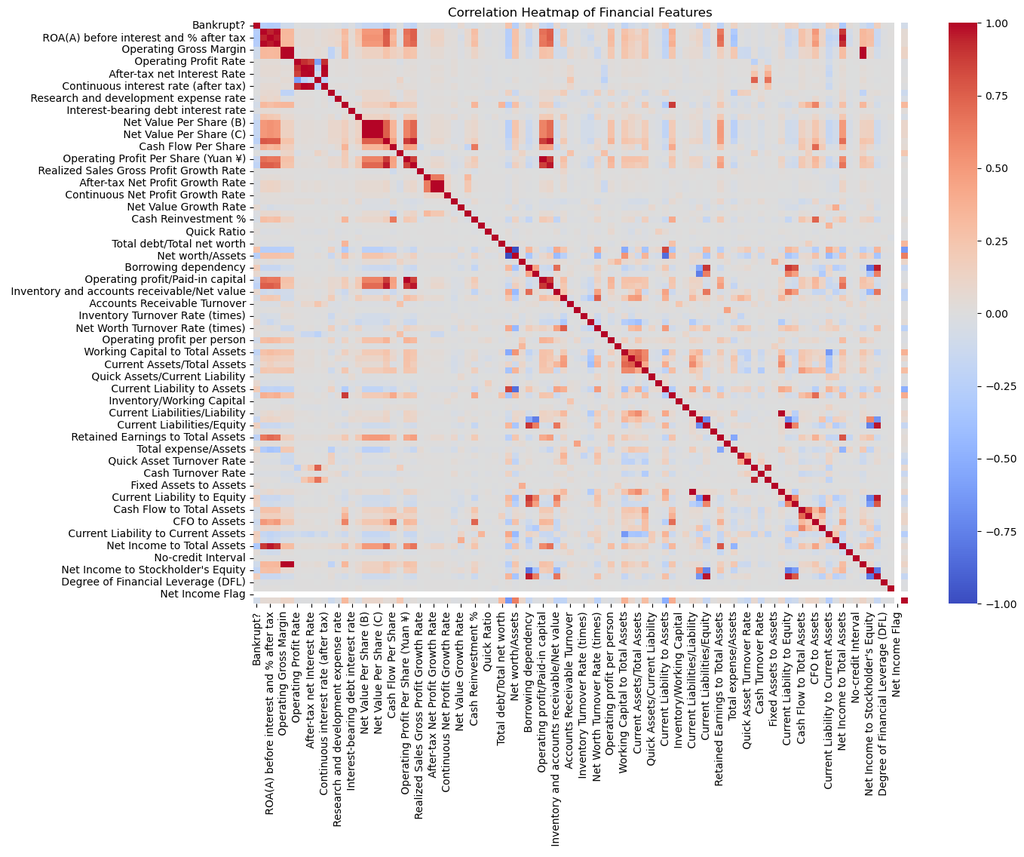

```python
plt.figure(figsize=(14,10))
sns.heatmap(correlation_matrix, cmap='coolwarm', center=0)
plt.title("Correlation Heatmap of Financial Features")
plt.show()
```

```python
# Correlation of all features with target variable
target_corr = correlation_matrix['Bankrupt?'].sort_values(ascending=False)
target_corr.head(15)
```

```
Bankrupt?                                       1.000000
 Debt ratio %                                   0.250161
 Current Liability to Assets                    0.194494
 Borrowing dependency                           0.176543
 Current Liability to Current Assets            0.171306
 Liability to Equity                            0.166812
 Current Liabilities/Equity                     0.153828
 Current Liability to Equity                    0.153828
 Liability-Assets Flag                          0.139212
 Total expense/Assets                           0.139049
 Equity to Long-term Liability                  0.139014
 Cash/Current Liability                         0.077921
 Inventory and accounts receivable/Net value    0.075278
 Fixed Assets Turnover Frequency                0.072818
 Contingent liabilities/Net worth               0.070455
Name: Bankrupt?, dtype: float64
```

```python
print("Top Positively Correlated Features:")
print(target_corr.head(10))

print("\nTop Negatively Correlated Features:")
print(target_corr.tail(10))
```

```
Top Positively Correlated Features:
Bankrupt?                               1.000000
 Debt ratio %                           0.250161
 Current Liability to Assets            0.194494
 Borrowing dependency                   0.176543
 Current Liability to Current Assets    0.171306
 Liability to Equity                    0.166812
 Current Liabilities/Equity             0.153828
 Current Liability to Equity            0.153828
 Liability-Assets Flag                  0.139212
 Total expense/Assets                   0.139049
Name: Bankrupt?, dtype: float64

Top Negatively Correlated Features:
Per Share Net profit before tax (Yuan ¥)                  -0.201395
Net profit before tax/Paid-in capital                     -0.207857
Retained Earnings to Total Assets                         -0.217779
Persistent EPS in the Last Four Seasons                   -0.219560
Net worth/Assets                                          -0.250161
ROA(C) before interest and depreciation before interest   -0.260807
ROA(B) before interest and depreciation after tax         -0.273051
ROA(A) before interest and % after tax                    -0.282941
Net Income to Total Assets                                -0.315457
Net Income Flag                                                 NaN
Name: Bankrupt?, dtype: float64
```

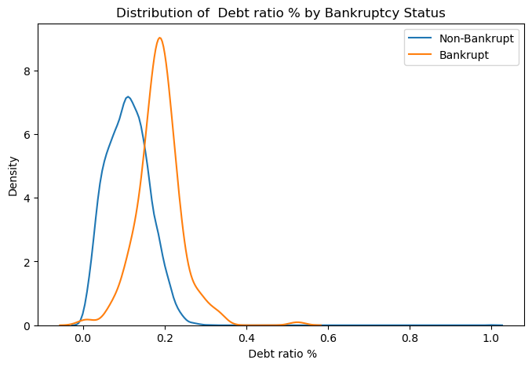

```python
feature = target_corr.index[1]

plt.figure(figsize=(8,5))
sns.kdeplot(df[df['Bankrupt?'] == 0][feature], label='Non-Bankrupt')
sns.kdeplot(df[df['Bankrupt?'] == 1][feature], label='Bankrupt')
plt.title(f"Distribution of {feature} by Bankruptcy Status")
plt.legend()
plt.show()
```

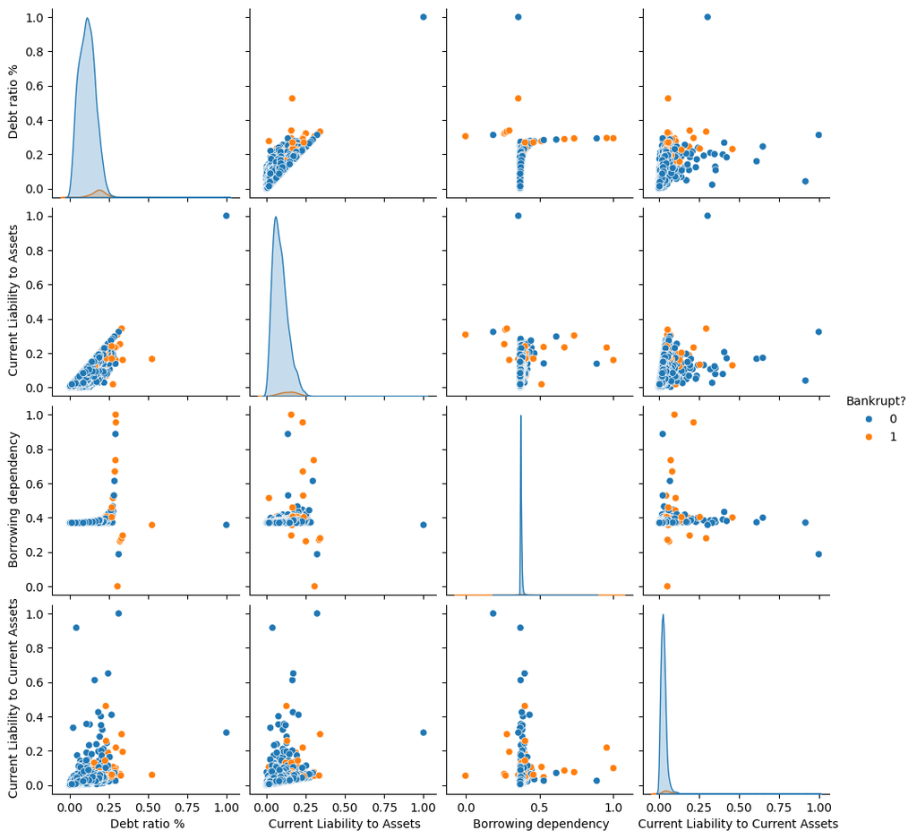

```python
sample_features = target_corr.index[1:5]
sns.pairplot(df[sample_features.tolist() + ['Bankrupt?']], hue='Bankrupt?')
plt.show()
```

### Step 6 | Correlation Analysis & Insights

```python
corr_matrix = df.corr()
```

```python
df.corr()
```

|  | Bankrupt? | ROA(C) before interest and depreciation before interest | ROA(A) before interest and % after tax | ROA(B) before interest and depreciation after tax | Operating Gross Margin | Realized Sales Gross Margin | Operating Profit Rate | Pre-tax net Interest Rate | After-tax net Interest Rate | Non-industry income and expenditure/revenue | ... | Net Income to Total Assets | Total assets to GNP price | No-credit Interval | Gross Profit to Sales | Net Income to Stockholder's Equity | Liability to Equity | Degree of Financial Leverage (DFL) | Interest Coverage Ratio (Interest expense to EBIT) | Net Income Flag | Equity to Liability |
| --- | --- | --- | --- | --- | --- | --- | --- | --- | --- | --- | --- | --- | --- | --- | --- | --- | --- | --- | --- | --- | --- |
| Bankrupt? | 1.000000 | -0.260807 | -0.282941 | -0.273051 | -0.100043 | -0.099445 | -0.000230 | -0.008517 | -0.008857 | -0.016593 | ... | -0.315457 | 0.035104 | -0.005547 | -0.100044 | -0.180987 | 0.166812 | 0.010508 | -0.005509 | NaN | -0.083048 |
| ROA(C) before interest and depreciation before interest | -0.260807 | 1.000000 | 0.940124 | 0.986849 | 0.334719 | 0.332755 | 0.035725 | 0.053419 | 0.049222 | 0.020501 | ... | 0.887670 | -0.071725 | 0.008135 | 0.334721 | 0.274287 | -0.143629 | -0.016575 | 0.010573 | NaN | 0.052416 |
| ROA(A) before interest and % after tax | -0.282941 | 0.940124 | 1.000000 | 0.955741 | 0.326969 | 0.324956 | 0.032053 | 0.053518 | 0.049474 | 0.029649 | ... | 0.961552 | -0.098900 | 0.011463 | 0.326971 | 0.291744 | -0.141039 | -0.011515 | 0.013372 | NaN | 0.057887 |
| ROA(B) before interest and depreciation after tax | -0.273051 | 0.986849 | 0.955741 | 1.000000 | 0.333749 | 0.331755 | 0.035212 | 0.053726 | 0.049952 | 0.022366 | ... | 0.912040 | -0.089088 | 0.007523 | 0.333750 | 0.280617 | -0.142838 | -0.014663 | 0.011473 | NaN | 0.056430 |
| Operating Gross Margin | -0.100043 | 0.334719 | 0.326969 | 0.333749 | 1.000000 | 0.999518 | 0.005745 | 0.032493 | 0.027175 | 0.051438 | ... | 0.300143 | 0.022672 | 0.004205 | 1.000000 | 0.075304 | -0.085434 | -0.011806 | -0.001167 | NaN | 0.120029 |
| ... | ... | ... | ... | ... | ... | ... | ... | ... | ... | ... | ... | ... | ... | ... | ... | ... | ... | ... | ... | ... | ... |
| Liability to Equity | 0.166812 | -0.143629 | -0.141039 | -0.142838 | -0.085434 | -0.085407 | 0.001541 | -0.004043 | -0.004390 | -0.011899 | ... | -0.159697 | 0.021982 | -0.003724 | -0.085434 | -0.791836 | 1.000000 | 0.002119 | 0.001487 | NaN | -0.159654 |
| Degree of Financial Leverage (DFL) | 0.010508 | -0.016575 | -0.011515 | -0.014663 | -0.011806 | -0.011268 | 0.000935 | 0.000855 | 0.000927 | -0.000556 | ... | -0.010463 | -0.001881 | -0.008812 | -0.011806 | -0.000093 | 0.002119 | 1.000000 | 0.016513 | NaN | -0.016739 |
| Interest Coverage Ratio (Interest expense to EBIT) | -0.005509 | 0.010573 | 0.013372 | 0.011473 | -0.001167 | -0.001158 | 0.000393 | 0.000984 | 0.000957 | 0.001024 | ... | 0.012746 | 0.000239 | 0.001027 | -0.001169 | 0.005147 | 0.001487 | 0.016513 | 1.000000 | NaN | -0.008339 |
| Net Income Flag | NaN | NaN | NaN | NaN | NaN | NaN | NaN | NaN | NaN | NaN | ... | NaN | NaN | NaN | NaN | NaN | NaN | NaN | NaN | NaN | NaN |
| Equity to Liability | -0.083048 | 0.052416 | 0.057887 | 0.056430 | 0.120029 | 0.120196 | -0.017071 | -0.014559 | -0.010900 | 0.012293 | ... | 0.073916 | 0.014871 | 0.050609 | 0.120027 | 0.029622 | -0.159654 | -0.016739 | -0.008339 | NaN | 1.000000 |

96 rows × 96 columns

```python
corr_matrix.head()
```

|  | Bankrupt? | ROA(C) before interest and depreciation before interest | ROA(A) before interest and % after tax | ROA(B) before interest and depreciation after tax | Operating Gross Margin | Realized Sales Gross Margin | Operating Profit Rate | Pre-tax net Interest Rate | After-tax net Interest Rate | Non-industry income and expenditure/revenue | ... | Net Income to Total Assets | Total assets to GNP price | No-credit Interval | Gross Profit to Sales | Net Income to Stockholder's Equity | Liability to Equity | Degree of Financial Leverage (DFL) | Interest Coverage Ratio (Interest expense to EBIT) | Net Income Flag | Equity to Liability |
| --- | --- | --- | --- | --- | --- | --- | --- | --- | --- | --- | --- | --- | --- | --- | --- | --- | --- | --- | --- | --- | --- |
| Bankrupt? | 1.000000 | -0.260807 | -0.282941 | -0.273051 | -0.100043 | -0.099445 | -0.000230 | -0.008517 | -0.008857 | -0.016593 | ... | -0.315457 | 0.035104 | -0.005547 | -0.100044 | -0.180987 | 0.166812 | 0.010508 | -0.005509 | NaN | -0.083048 |
| ROA(C) before interest and depreciation before interest | -0.260807 | 1.000000 | 0.940124 | 0.986849 | 0.334719 | 0.332755 | 0.035725 | 0.053419 | 0.049222 | 0.020501 | ... | 0.887670 | -0.071725 | 0.008135 | 0.334721 | 0.274287 | -0.143629 | -0.016575 | 0.010573 | NaN | 0.052416 |
| ROA(A) before interest and % after tax | -0.282941 | 0.940124 | 1.000000 | 0.955741 | 0.326969 | 0.324956 | 0.032053 | 0.053518 | 0.049474 | 0.029649 | ... | 0.961552 | -0.098900 | 0.011463 | 0.326971 | 0.291744 | -0.141039 | -0.011515 | 0.013372 | NaN | 0.057887 |
| ROA(B) before interest and depreciation after tax | -0.273051 | 0.986849 | 0.955741 | 1.000000 | 0.333749 | 0.331755 | 0.035212 | 0.053726 | 0.049952 | 0.022366 | ... | 0.912040 | -0.089088 | 0.007523 | 0.333750 | 0.280617 | -0.142838 | -0.014663 | 0.011473 | NaN | 0.056430 |
| Operating Gross Margin | -0.100043 | 0.334719 | 0.326969 | 0.333749 | 1.000000 | 0.999518 | 0.005745 | 0.032493 | 0.027175 | 0.051438 | ... | 0.300143 | 0.022672 | 0.004205 | 1.000000 | 0.075304 | -0.085434 | -0.011806 | -0.001167 | NaN | 0.120029 |

5 rows × 96 columns

```python
target_corr = corr_matrix['Bankrupt?'].sort_values(ascending=False)
target_corr
```

```
Bankrupt?                                                   1.000000
 Debt ratio %                                               0.250161
 Current Liability to Assets                                0.194494
 Borrowing dependency                                       0.176543
 Current Liability to Current Assets                        0.171306
                                                              ...
 ROA(C) before interest and depreciation before interest   -0.260807
 ROA(B) before interest and depreciation after tax         -0.273051
 ROA(A) before interest and % after tax                    -0.282941
 Net Income to Total Assets                                -0.315457
 Net Income Flag                                                 NaN
Name: Bankrupt?, Length: 96, dtype: float64
```

```python
top_positive = target_corr.head(10)
top_positive
```

```
Bankrupt?                               1.000000
 Debt ratio %                           0.250161
 Current Liability to Assets            0.194494
 Borrowing dependency                   0.176543
 Current Liability to Current Assets    0.171306
 Liability to Equity                    0.166812
 Current Liabilities/Equity             0.153828
 Current Liability to Equity            0.153828
 Liability-Assets Flag                  0.139212
 Total expense/Assets                   0.139049
Name: Bankrupt?, dtype: float64
```

```python
top_negative = target_corr.tail(10)
top_negative
```

```
Per Share Net profit before tax (Yuan ¥)                  -0.201395
Net profit before tax/Paid-in capital                     -0.207857
Retained Earnings to Total Assets                         -0.217779
Persistent EPS in the Last Four Seasons                   -0.219560
Net worth/Assets                                          -0.250161
ROA(C) before interest and depreciation before interest   -0.260807
ROA(B) before interest and depreciation after tax         -0.273051
ROA(A) before interest and % after tax                    -0.282941
Net Income to Total Assets                                -0.315457
Net Income Flag                                                 NaN
Name: Bankrupt?, dtype: float64
```

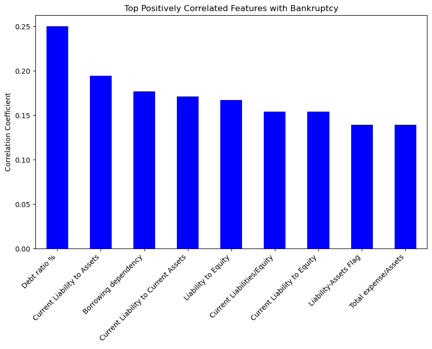

```python
plt.figure(figsize=(10,6))
top_positive[1:].plot(kind='bar', color='blue')
plt.title("Top Positively Correlated Features with Bankruptcy")
plt.ylabel("Correlation Coefficient")
plt.xticks(rotation=45, ha='right')
plt.show()
```

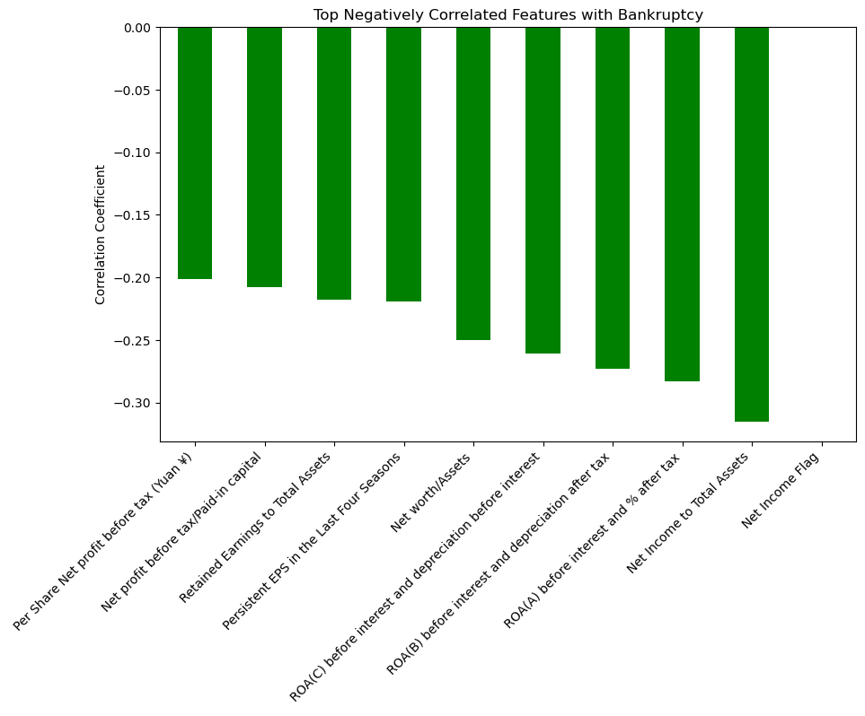

```python
plt.figure(figsize=(10,6))
top_negative.plot(kind='bar', color='green')
plt.title("Top Negatively Correlated Features with Bankruptcy")
plt.ylabel("Correlation Coefficient")
plt.xticks(rotation=45, ha='right')
plt.show()
```

```python
threshold = 0.2

selected_features = target_corr[abs(target_corr) >= threshold].index
selected_features
```

```
Index(['Bankrupt?', ' Debt ratio %',
       ' Per Share Net profit before tax (Yuan ¥)',
       ' Net profit before tax/Paid-in capital',
       ' Retained Earnings to Total Assets',
       ' Persistent EPS in the Last Four Seasons', ' Net worth/Assets',
       ' ROA(C) before interest and depreciation before interest',
       ' ROA(B) before interest and depreciation after tax',
       ' ROA(A) before interest and % after tax',
       ' Net Income to Total Assets'],
      dtype='object')
```

```python
X = df[selected_features].drop('Bankrupt?', axis=1)
y = df['Bankrupt?']

X.shape, y.shape
```

```
((6819, 10), (6819,))
```

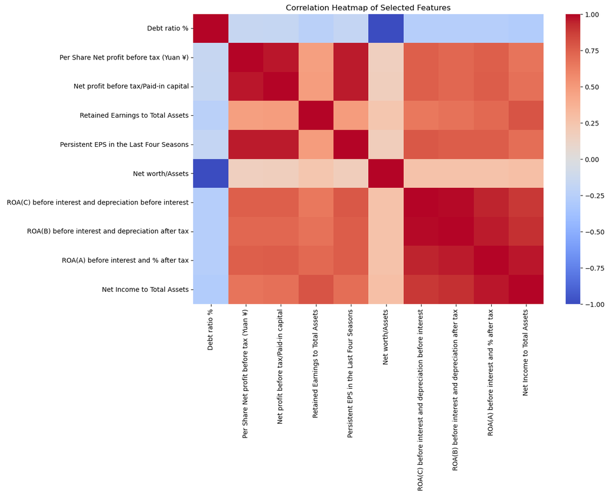

```python
plt.figure(figsize=(12,8))
sns.heatmap(X.corr(), cmap='coolwarm', center=0)
plt.title("Correlation Heatmap of Selected Features")
plt.show()
```

## Correlation Analysis & Insights

### Step 7 | Feature Selection

```python
X = df.drop('Bankrupt?', axis=1)
y = df['Bankrupt?']

X.shape, y.shape
```

```
((6819, 95), (6819,))
```

```python
corr_with_target = df.corr()['Bankrupt?'].abs().sort_values(ascending=False)
corr_with_target
```

```
Bankrupt?                                                   1.000000
 Net Income to Total Assets                                 0.315457
 ROA(A) before interest and % after tax                     0.282941
 ROA(B) before interest and depreciation after tax          0.273051
 ROA(C) before interest and depreciation before interest    0.260807
                                                              ...
 Long-term Liability to Current Assets                      0.000778
 Cash Flow to Sales                                         0.000479
 Realized Sales Gross Profit Growth Rate                    0.000458
 Operating Profit Rate                                      0.000230
 Net Income Flag                                                 NaN
Name: Bankrupt?, Length: 96, dtype: float64
```

```python
top_n = 15
selected_features_corr = corr_with_target[1:top_n+1].index.tolist()
selected_features_corr
```

```
[' Net Income to Total Assets',
 ' ROA(A) before interest and % after tax',
 ' ROA(B) before interest and depreciation after tax',
 ' ROA(C) before interest and depreciation before interest',
 ' Net worth/Assets',
 ' Debt ratio %',
 ' Persistent EPS in the Last Four Seasons',
 ' Retained Earnings to Total Assets',
 ' Net profit before tax/Paid-in capital',
 ' Per Share Net profit before tax (Yuan ¥)',
 ' Current Liability to Assets',
 ' Working Capital to Total Assets',
 " Net Income to Stockholder's Equity",
 ' Borrowing dependency',
 ' Current Liability to Current Assets']
```

```python
X_corr = df[selected_features_corr]
X_corr.shape
```

```
(6819, 15)
```

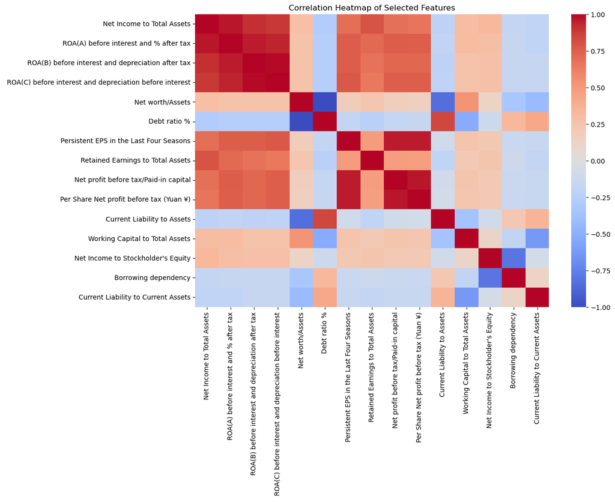

```python
import seaborn as sns
import matplotlib.pyplot as plt

plt.figure(figsize=(12,8))
sns.heatmap(X_corr.corr(), cmap='coolwarm', center=0)
plt.title("Correlation Heatmap of Selected Features")
plt.show()
```

```python
from sklearn.feature_selection import VarianceThreshold
var_selector = VarianceThreshold(threshold=0.0001)
X_var = var_selector.fit_transform(X_corr)
X_var.shape
```

```
(6819, 15)
```

```python
selected_var_features = X_corr.columns[var_selector.get_support()]
selected_var_features
```

```
Index([' Net Income to Total Assets',
       ' ROA(A) before interest and % after tax',
       ' ROA(B) before interest and depreciation after tax',
       ' ROA(C) before interest and depreciation before interest',
       ' Net worth/Assets', ' Debt ratio %',
       ' Persistent EPS in the Last Four Seasons',
       ' Retained Earnings to Total Assets',
       ' Net profit before tax/Paid-in capital',
       ' Per Share Net profit before tax (Yuan ¥)',
       ' Current Liability to Assets', ' Working Capital to Total Assets',
       ' Net Income to Stockholder's Equity', ' Borrowing dependency',
       ' Current Liability to Current Assets'],
      dtype='object')
```

```python
from sklearn.feature_selection import SelectKBest, f_classif
selector = SelectKBest(score_func=f_classif, k=10)
X_univariate = selector.fit_transform(X_corr, y)
X_univariate.shape
```

```
(6819, 10)
```

```python
final_features = X_corr.columns[selector.get_support()]
final_features
```

```
Index([' Net Income to Total Assets',
       ' ROA(A) before interest and % after tax',
       ' ROA(B) before interest and depreciation after tax',
       ' ROA(C) before interest and depreciation before interest',
       ' Net worth/Assets', ' Debt ratio %',
       ' Persistent EPS in the Last Four Seasons',
       ' Retained Earnings to Total Assets',
       ' Net profit before tax/Paid-in capital',
       ' Per Share Net profit before tax (Yuan ¥)'],
      dtype='object')
```

```python
X_final = df[final_features]
X_final.shape
```

```
(6819, 10)
```

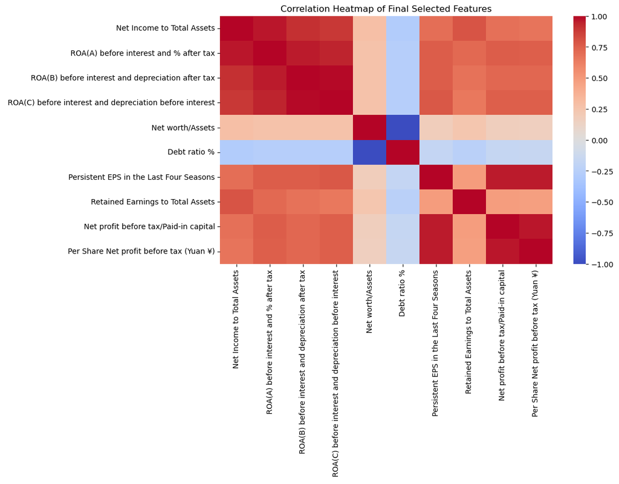

```python
plt.figure(figsize=(10,6))
sns.heatmap(X_final.corr(), cmap='coolwarm', center=0)
plt.title("Correlation Heatmap of Final Selected Features")
plt.show()
```

```python
print("Initial number of features:", df.shape[1] - 1)
print("Features after correlation selection:", len(selected_features_corr))
print("Features after variance threshold:", len(selected_var_features))
print("Final selected features:", len(final_features))
```

```
Initial number of features: 95
Features after correlation selection: 15
Features after variance threshold: 15
Final selected features: 10
```

## Feature Selection

Feature selection was performed to reduce dimensionality and improve model performance. Initially, features were selected based on their correlation with the target variable. Low-variance features were removed to eliminate non-informative variables. Finally, univariate feature selection using ANOVA F-test was applied to select the most significant financial indicators for bankruptcy prediction.

### Evaluation Metrics

- Accuracy: Measures the overall correctness of the model.
- Precision: Indicates how many predicted bankrupt companies were actually bankrupt.
- Recall: Measures the model’s ability to identify actual bankrupt companies.
- F1-Score: Harmonic mean of precision and recall, suitable for imbalanced datasets.

### Step 8 | Data Preprocessing

```python
X = df[final_features]
y = df['Bankrupt?']
X.shape, y.shape
```

```
((6819, 10), (6819,))
```

```python
from sklearn.model_selection import train_test_split
X_train, X_test, y_train, y_test = train_test_split(
    X,
    y,
    test_size=0.2,
    random_state=42,
    stratify=y
)
X_train.shape, X_test.shape
```

```
((5455, 10), (1364, 10))
```

```python
from sklearn.preprocessing import StandardScaler
scaler = StandardScaler()
X_train_scaled = scaler.fit_transform(X_train)
X_test_scaled = scaler.transform(X_test)
X_train_scaled.shape, X_test_scaled.shape
```

```
((5455, 10), (1364, 10))
```

```python
print("Training set class distribution:")
print(y_train.value_counts())
print("\nTest set class distribution:")
print(y_test.value_counts())
```

```
Training set class distribution:
Bankrupt?
0    5279
1     176
Name: count, dtype: int64

Test set class distribution:
Bankrupt?
0    1320
1      44
Name: count, dtype: int64
```

```python
from imblearn.over_sampling import SMOTE
smote = SMOTE(random_state=42)
X_train_balanced, y_train_balanced = smote.fit_resample(
    X_train_scaled,
    y_train
)
X_train_balanced.shape, y_train_balanced.shape
```

```
((10558, 10), (10558,))
```

```python
import pandas as pd
pd.Series(y_train_balanced).value_counts()
```

```
Bankrupt?
0    5279
1    5279
Name: count, dtype: int64
```

```python
print("Final Training Shape:", X_train_balanced.shape)
print("Final Test Shape:", X_test_scaled.shape)
```

```
Final Training Shape: (10558, 10)
Final Test Shape: (1364, 10)
```

### Data Preprocessing

Data preprocessing was performed to prepare the dataset for machine learning models. The data was split into training and testing sets while maintaining class distribution. Feature scaling was applied using standardization to ensure uniform feature ranges. Due to significant class imbalance, SMOTE was used to balance the training data by generating synthetic samples for bankrupt companies. This preprocessing pipeline improves model stability and predictive performance.

### Step 9| Feature Scaling & Train-Test Split

```python
X = df[final_features]
y = df['Bankrupt?']
X.shape, y.shape
```

```
((6819, 10), (6819,))
```

```python
from sklearn.model_selection import train_test_split
X_train, X_test, y_train, y_test = train_test_split(
    X,
    y,
    test_size=0.2,
    random_state=42,
    stratify=y
)

X_train.shape, X_test.shape
```

```
((5455, 10), (1364, 10))
```

```python
print("Training set distribution:")
print(y_train.value_counts())
print("\nTest set distribution:")
print(y_test.value_counts())
```

```
Training set distribution:
Bankrupt?
0    5279
1     176
Name: count, dtype: int64

Test set distribution:
Bankrupt?
0    1320
1      44
Name: count, dtype: int64
```

```python
from sklearn.preprocessing import StandardScaler
scaler = StandardScaler()
X_train_scaled = scaler.fit_transform(X_train)
X_test_scaled = scaler.transform(X_test)
X_train_scaled.shape, X_test_scaled.shape
```

```
((5455, 10), (1364, 10))
```

```python
X_train_scaled = pd.DataFrame(X_train_scaled, columns=final_features)
X_test_scaled = pd.DataFrame(X_test_scaled, columns=final_features)
```

```python
X_train_scaled
```

|  | Net Income to Total Assets | ROA(A) before interest and % after tax | ROA(B) before interest and depreciation after tax | ROA(C) before interest and depreciation before interest | Net worth/Assets | Debt ratio % | Persistent EPS in the Last Four Seasons | Retained Earnings to Total Assets | Net profit before tax/Paid-in capital | Per Share Net profit before tax (Yuan ¥) |
| --- | --- | --- | --- | --- | --- | --- | --- | --- | --- | --- |
| 0 | -0.019743 | -0.117303 | -0.135577 | -0.176677 | 1.083483 | -1.083483 | -0.216287 | -0.060811 | -0.237991 | -0.214233 |
| 1 | 0.508205 | 0.504173 | 0.333551 | 0.496220 | -0.870610 | 0.870610 | 0.649462 | 0.292229 | 0.791573 | 0.737985 |
| 2 | 0.530851 | 0.444945 | 0.221065 | 0.363741 | 0.899556 | -0.899556 | 0.074272 | 0.285853 | 0.167204 | 0.166654 |
| 3 | -0.239640 | -0.320846 | -0.519251 | -0.575729 | -1.059554 | 1.059554 | -0.373427 | 0.024344 | -0.372380 | -0.370927 |
| 4 | -1.272760 | -1.753995 | -1.962388 | -1.870631 | 1.826998 | -1.826998 | -0.806301 | -0.670633 | -0.735815 | -0.850651 |
| ... | ... | ... | ... | ... | ... | ... | ... | ... | ... | ... |
| 5450 | 0.105601 | 0.092915 | 0.660546 | 0.756331 | -0.683338 | 0.683338 | 0.352972 | 0.318291 | 0.252495 | 0.248617 |
| 5451 | -0.388376 | -0.454318 | -0.373629 | -0.378626 | -0.805399 | 0.805399 | -0.337848 | -0.170742 | -0.499178 | -0.493871 |
| 5452 | 1.704199 | 2.293524 | 2.221401 | 1.952681 | 1.618546 | -1.618546 | 2.760466 | 1.234898 | 2.290615 | 2.271175 |
| 5453 | 1.229745 | 1.290820 | 1.147114 | 1.365412 | 0.722316 | -0.722316 | 0.631672 | 0.683869 | 0.765252 | 0.713878 |
| 5454 | 0.101183 | 0.134625 | -0.044019 | -0.057930 | -0.394627 | 0.394627 | -0.044323 | 0.128932 | 0.014845 | 0.009960 |

5455 rows × 10 columns

```python
print("Scaled Training Data Shape:", X_train_scaled.shape)
print("Scaled Test Data Shape:", X_test_scaled.shape)
```

```
Scaled Training Data Shape: (5455, 10)
Scaled Test Data Shape: (1364, 10)
```

```python
X_train_scaled
```

|  | Net Income to Total Assets | ROA(A) before interest and % after tax | ROA(B) before interest and depreciation after tax | ROA(C) before interest and depreciation before interest | Net worth/Assets | Debt ratio % | Persistent EPS in the Last Four Seasons | Retained Earnings to Total Assets | Net profit before tax/Paid-in capital | Per Share Net profit before tax (Yuan ¥) |
| --- | --- | --- | --- | --- | --- | --- | --- | --- | --- | --- |
| 0 | -0.019743 | -0.117303 | -0.135577 | -0.176677 | 1.083483 | -1.083483 | -0.216287 | -0.060811 | -0.237991 | -0.214233 |
| 1 | 0.508205 | 0.504173 | 0.333551 | 0.496220 | -0.870610 | 0.870610 | 0.649462 | 0.292229 | 0.791573 | 0.737985 |
| 2 | 0.530851 | 0.444945 | 0.221065 | 0.363741 | 0.899556 | -0.899556 | 0.074272 | 0.285853 | 0.167204 | 0.166654 |
| 3 | -0.239640 | -0.320846 | -0.519251 | -0.575729 | -1.059554 | 1.059554 | -0.373427 | 0.024344 | -0.372380 | -0.370927 |
| 4 | -1.272760 | -1.753995 | -1.962388 | -1.870631 | 1.826998 | -1.826998 | -0.806301 | -0.670633 | -0.735815 | -0.850651 |
| ... | ... | ... | ... | ... | ... | ... | ... | ... | ... | ... |
| 5450 | 0.105601 | 0.092915 | 0.660546 | 0.756331 | -0.683338 | 0.683338 | 0.352972 | 0.318291 | 0.252495 | 0.248617 |
| 5451 | -0.388376 | -0.454318 | -0.373629 | -0.378626 | -0.805399 | 0.805399 | -0.337848 | -0.170742 | -0.499178 | -0.493871 |
| 5452 | 1.704199 | 2.293524 | 2.221401 | 1.952681 | 1.618546 | -1.618546 | 2.760466 | 1.234898 | 2.290615 | 2.271175 |
| 5453 | 1.229745 | 1.290820 | 1.147114 | 1.365412 | 0.722316 | -0.722316 | 0.631672 | 0.683869 | 0.765252 | 0.713878 |
| 5454 | 0.101183 | 0.134625 | -0.044019 | -0.057930 | -0.394627 | 0.394627 | -0.044323 | 0.128932 | 0.014845 | 0.009960 |

5455 rows × 10 columns

```python
X_test_scaled
```

|  | Net Income to Total Assets | ROA(A) before interest and % after tax | ROA(B) before interest and depreciation after tax | ROA(C) before interest and depreciation before interest | Net worth/Assets | Debt ratio % | Persistent EPS in the Last Four Seasons | Retained Earnings to Total Assets | Net profit before tax/Paid-in capital | Per Share Net profit before tax (Yuan ¥) |
| --- | --- | --- | --- | --- | --- | --- | --- | --- | --- | --- |
| 0 | -0.043884 | -0.025541 | -0.010883 | -0.019964 | -0.824907 | 0.824907 | -0.216287 | 0.003676 | -0.168138 | -0.175662 |
| 1 | -0.099412 | -0.154007 | -0.363165 | -0.305925 | 0.120371 | -0.120371 | -0.248901 | 0.369667 | -0.178768 | -0.185304 |
| 2 | 0.796450 | 0.928779 | 0.922142 | 0.827417 | 0.093060 | -0.093060 | 0.892583 | 0.427686 | 0.768795 | 0.807895 |
| 3 | 1.792658 | 2.058280 | 2.545779 | 2.642542 | 0.936898 | -0.936898 | 1.601193 | 1.071570 | 1.588295 | 1.509401 |
| 4 | -0.621281 | -0.732105 | -0.936932 | -0.891579 | 1.783524 | -1.783524 | -0.631372 | -0.240238 | -0.531320 | -0.525210 |
| ... | ... | ... | ... | ... | ... | ... | ... | ... | ... | ... |
| 1359 | 0.242160 | 0.214707 | -0.322182 | -0.322080 | -0.548458 | 0.548458 | 0.065378 | 0.147378 | 0.636936 | 0.610219 |
| 1360 | -0.264125 | -0.283308 | -0.309974 | -0.366509 | -1.071259 | 1.071259 | -0.411970 | -0.108550 | -0.467289 | -0.469764 |
| 1361 | 0.429481 | 0.352350 | 0.178338 | 0.296694 | -0.336105 | 0.336105 | 0.438954 | 0.385397 | 0.552910 | 0.537899 |
| 1362 | -0.062049 | -0.159847 | -0.358805 | -0.399629 | -1.122536 | 1.122536 | -0.136235 | -0.007585 | -0.211416 | -0.149144 |
| 1363 | -0.549685 | -0.550250 | -0.710216 | -0.893194 | -1.353839 | 1.353839 | -0.797407 | -0.220417 | -0.808705 | -0.872347 |

1364 rows × 10 columns

### Train-Test Split and Feature Scaling

The dataset was divided into training and testing sets using a stratified split to preserve the original class distribution. Feature scaling was applied using standardization to bring all numerical features to a common scale. The scaler was fitted only on the training data to prevent data leakage and then applied to the test data.

### Step 10| Logistic Regression Models

```python
from sklearn.linear_model import LogisticRegression
from sklearn.metrics import (
    accuracy_score,
    precision_score,
    recall_score,
    f1_score,
    confusion_matrix,
    classification_report
)
```

```python
lr_model = LogisticRegression(
    max_iter=1000,
    random_state=42
)
lr_model.fit(X_train_scaled, y_train)
```

```
LogisticRegression(max_iter=1000, random_state=42)
```

```python
y_pred_lr = lr_model.predict(X_test_scaled)
```

```python
y_pred_lr
```

```
array([0, 0, 0, ..., 0, 0, 0], shape=(1364,))
```

```python
accuracy = accuracy_score(y_test, y_pred_lr)
precision = precision_score(y_test, y_pred_lr)
recall = recall_score(y_test, y_pred_lr)
f1 = f1_score(y_test, y_pred_lr)
print("Logistic Regression Performance")
print("Accuracy :", accuracy)
print("Precision:", precision)
print("Recall   :", recall)
print("F1 Score :", f1)
```

```
Logistic Regression Performance
Accuracy : 0.969208211143695
Precision: 0.5714285714285714
Recall   : 0.18181818181818182
F1 Score : 0.27586206896551724
```

```python
cm = confusion_matrix(y_test, y_pred_lr)
```

```python
cm
```

```
array([[1314,    6],
       [  36,    8]])
```

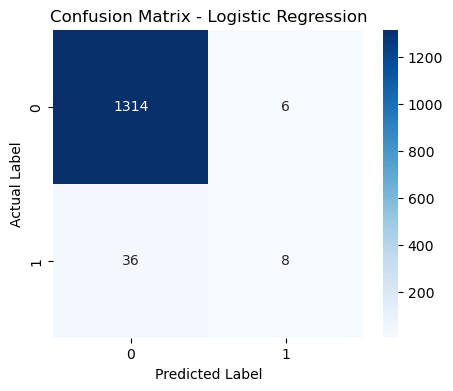

```python
import seaborn as sns
import matplotlib.pyplot as plt
plt.figure(figsize=(5,4))
sns.heatmap(
    cm,
    annot=True,
    fmt='d',
    cmap='Blues'
)
plt.xlabel("Predicted Label")
plt.ylabel("Actual Label")
plt.title("Confusion Matrix - Logistic Regression")
plt.show()
```

```python
print(classification_report(y_test, y_pred_lr))
```

```
              precision    recall  f1-score   support

           0       0.97      1.00      0.98      1320
           1       0.57      0.18      0.28        44

    accuracy                           0.97      1364
   macro avg       0.77      0.59      0.63      1364
weighted avg       0.96      0.97      0.96      1364
```

```python
coefficients = pd.DataFrame({
    'Feature': final_features,
    'Coefficient': lr_model.coef_[0]
}).sort_values(by='Coefficient', ascending=False)
coefficients
```

|  | Feature | Coefficient |
| --- | --- | --- |
| 9 | Per Share Net profit before tax (Yuan ¥) | 0.899251 |
| 5 | Debt ratio % | 0.473481 |
| 7 | Retained Earnings to Total Assets | 0.279821 |
| 2 | ROA(B) before interest and depreciation after... | 0.154112 |
| 1 | ROA(A) before interest and % after tax | 0.087545 |
| 3 | ROA(C) before interest and depreciation befor... | -0.422675 |
| 4 | Net worth/Assets | -0.473481 |
| 8 | Net profit before tax/Paid-in capital | -0.518188 |
| 0 | Net Income to Total Assets | -0.578860 |
| 6 | Persistent EPS in the Last Four Seasons | -1.071380 |

```python
lr_weighted = LogisticRegression(
    max_iter=1000,
    class_weight='balanced',
    random_state=42
)
lr_weighted.fit(X_train_scaled, y_train)
y_pred_weighted = lr_weighted.predict(X_test_scaled)
print(classification_report(y_test, y_pred_weighted))
```

```
              precision    recall  f1-score   support

           0       0.99      0.88      0.93      1320
           1       0.19      0.84      0.30        44

    accuracy                           0.88      1364
   macro avg       0.59      0.86      0.62      1364
weighted avg       0.97      0.88      0.91      1364
```

### Logistic Regression

Logistic Regression was implemented as a baseline classification model for bankruptcy prediction. The model was trained on scaled financial features and evaluated using accuracy, precision, recall, and F1-score. Due to class imbalance, a class-weighted version of Logistic Regression was also evaluated to improve minority class prediction performance.

### Step 11| Decision Tree Model

```python
from sklearn.tree import DecisionTreeClassifier
from sklearn.metrics import (
    accuracy_score,
    precision_score,
    recall_score,
    f1_score,
    confusion_matrix,
    classification_report
)
```

```python
dt_model = DecisionTreeClassifier(
    random_state=42
)
dt_model.fit(X_train_scaled, y_train)
```

```
DecisionTreeClassifier(random_state=42)
```

```python
y_pred_dt = dt_model.predict(X_test_scaled)
```

```python
y_pred_dt
```

```
array([0, 0, 0, ..., 0, 0, 0], shape=(1364,))
```

```python
accuracy_dt = accuracy_score(y_test, y_pred_dt)
precision_dt = precision_score(y_test, y_pred_dt)
recall_dt = recall_score(y_test, y_pred_dt)
f1_dt = f1_score(y_test, y_pred_dt)
print("Decision Tree Performance")
print("Accuracy :", accuracy_dt)
print("Precision:", precision_dt)
print("Recall   :", recall_dt)
print("F1 Score :", f1_dt)
```

```
Decision Tree Performance
Accuracy : 0.9633431085043989
Precision: 0.4318181818181818
Recall   : 0.4318181818181818
F1 Score : 0.4318181818181818
```

```python
cm_dt = confusion_matrix(y_test, y_pred_dt)
cm_dt
```

```
array([[1295,   25],
       [  25,   19]])
```

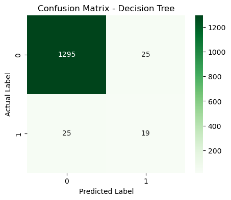

```python
import seaborn as sns
import matplotlib.pyplot as plt

plt.figure(figsize=(5,4))
sns.heatmap(
    cm_dt,
    annot=True,
    fmt='d',
    cmap='Greens'
)
plt.xlabel("Predicted Label")
plt.ylabel("Actual Label")
plt.title("Confusion Matrix - Decision Tree")
plt.show()
```

```python
print(classification_report(y_test, y_pred_dt))
```

```
              precision    recall  f1-score   support

           0       0.98      0.98      0.98      1320
           1       0.43      0.43      0.43        44

    accuracy                           0.96      1364
   macro avg       0.71      0.71      0.71      1364
weighted avg       0.96      0.96      0.96      1364
```

```python
feature_importance_dt = pd.DataFrame({
    'Feature': final_features,
    'Importance': dt_model.feature_importances_
}).sort_values(by='Importance', ascending=False)

feature_importance_dt
```

|  | Feature | Importance |
| --- | --- | --- |
| 6 | Persistent EPS in the Last Four Seasons | 0.266363 |
| 5 | Debt ratio % | 0.137791 |
| 2 | ROA(B) before interest and depreciation after... | 0.123779 |
| 9 | Per Share Net profit before tax (Yuan ¥) | 0.088168 |
| 8 | Net profit before tax/Paid-in capital | 0.081802 |
| 3 | ROA(C) before interest and depreciation befor... | 0.080756 |
| 1 | ROA(A) before interest and % after tax | 0.072722 |
| 0 | Net Income to Total Assets | 0.068478 |
| 7 | Retained Earnings to Total Assets | 0.059277 |
| 4 | Net worth/Assets | 0.020865 |

```python
dt_pruned = DecisionTreeClassifier(
    max_depth=5,
    min_samples_split=10,
    random_state=42
)

dt_pruned.fit(X_train_scaled, y_train)

y_pred_dt_pruned = dt_pruned.predict(X_test_scaled)

print(classification_report(y_test, y_pred_dt_pruned))
```

```
              precision    recall  f1-score   support

           0       0.97      1.00      0.99      1320
           1       0.75      0.14      0.23        44

    accuracy                           0.97      1364
   macro avg       0.86      0.57      0.61      1364
weighted avg       0.96      0.97      0.96      1364
```

### Step 12| Random Forest Model

```python
from sklearn.ensemble import RandomForestClassifier
from sklearn.metrics import (
    accuracy_score,
    precision_score,
    recall_score,
    f1_score,
    confusion_matrix,
    classification_report
)
```

```python
rf_model = RandomForestClassifier(
    n_estimators=200,
    random_state=42,
    n_jobs=-1
)
rf_model.fit(X_train_scaled, y_train)
```

```
RandomForestClassifier(n_estimators=200, n_jobs=-1, random_state=42)
```

```python
y_pred_rf = rf_model.predict(X_test_scaled)
```

```python
y_pred_rf
```

```
array([0, 0, 0, ..., 0, 0, 0], shape=(1364,))
```

```python
print("Random Forest Performance")
print("Accuracy :", accuracy_score(y_test, y_pred_rf))
print("Precision:", precision_score(y_test, y_pred_rf))
print("Recall   :", recall_score(y_test, y_pred_rf))
print("F1 Score :", f1_score(y_test, y_pred_rf))
```

```
Random Forest Performance
Accuracy : 0.9699413489736071
Precision: 0.6
Recall   : 0.20454545454545456
F1 Score : 0.3050847457627119
```

```python
cm_rf = confusion_matrix(y_test, y_pred_rf)
cm_rf
```

```
array([[1314,    6],
       [  35,    9]])
```

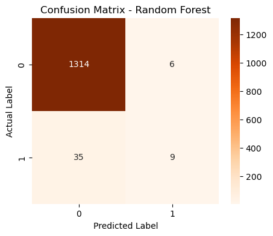

```python
import seaborn as sns
import matplotlib.pyplot as plt

plt.figure(figsize=(5,4))
sns.heatmap(cm_rf, annot=True, fmt='d', cmap='Oranges')
plt.xlabel("Predicted Label")
plt.ylabel("Actual Label")
plt.title("Confusion Matrix - Random Forest")
plt.show()
```

```python
rf_importance = pd.DataFrame({
    'Feature': final_features,
    'Importance': rf_model.feature_importances_
}).sort_values(by='Importance', ascending=False)

rf_importance
```

|  | Feature | Importance |
| --- | --- | --- |
| 6 | Persistent EPS in the Last Four Seasons | 0.134418 |
| 8 | Net profit before tax/Paid-in capital | 0.119926 |
| 5 | Debt ratio % | 0.113133 |
| 4 | Net worth/Assets | 0.111647 |
| 9 | Per Share Net profit before tax (Yuan ¥) | 0.109657 |
| 0 | Net Income to Total Assets | 0.096559 |
| 1 | ROA(A) before interest and % after tax | 0.089050 |
| 7 | Retained Earnings to Total Assets | 0.082513 |
| 3 | ROA(C) before interest and depreciation befor... | 0.072908 |
| 2 | ROA(B) before interest and depreciation after... | 0.070191 |

```python
from sklearn.ensemble import GradientBoostingClassifier
```

```python
gb_model = GradientBoostingClassifier(
    n_estimators=150,
    learning_rate=0.1,
    random_state=42
)
gb_model.fit(X_train_scaled, y_train)
```

```
GradientBoostingClassifier(n_estimators=150, random_state=42)
```

```python
y_pred_gb = gb_model.predict(X_test_scaled)
```

```python
print("Gradient Boosting Performance")
print("Accuracy :", accuracy_score(y_test, y_pred_gb))
print("Precision:", precision_score(y_test, y_pred_gb))
print("Recall   :", recall_score(y_test, y_pred_gb))
print("F1 Score :", f1_score(y_test, y_pred_gb))
```

```
Gradient Boosting Performance
Accuracy : 0.967741935483871
Precision: 0.5
Recall   : 0.20454545454545456
F1 Score : 0.2903225806451613
```

```python
cm_gb = confusion_matrix(y_test, y_pred_gb)
cm_gb
```

```
array([[1311,    9],
       [  35,    9]])
```

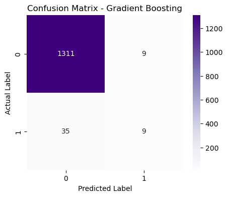

```python
plt.figure(figsize=(5,4))
sns.heatmap(cm_gb, annot=True, fmt='d', cmap='Purples')
plt.xlabel("Predicted Label")
plt.ylabel("Actual Label")
plt.title("Confusion Matrix - Gradient Boosting")
plt.show()
```

### Step 13| Gradient Boosting Models

```python
from sklearn.ensemble import GradientBoostingClassifier
from sklearn.metrics import (
    accuracy_score,
    precision_score,
    recall_score,
    f1_score,
    confusion_matrix,
    classification_report
)
import matplotlib.pyplot as plt
import seaborn as sns
```

```python
gb_model = GradientBoostingClassifier(
    n_estimators=150,
    learning_rate=0.1,
    max_depth=3,
    random_state=42
)
```

```python
gb_model
```

```
GradientBoostingClassifier(n_estimators=150, random_state=42)
```

```python
gb_model.fit(X_train_scaled, y_train)
```

```
GradientBoostingClassifier(n_estimators=150, random_state=42)
```

```python
accuracy_gb = accuracy_score(y_test, y_pred_gb)
precision_gb = precision_score(y_test, y_pred_gb)
recall_gb = recall_score(y_test, y_pred_gb)
f1_gb = f1_score(y_test, y_pred_gb)

print("Gradient Boosting Performance")
print("Accuracy :", accuracy_gb)
print("Precision:", precision_gb)
print("Recall   :", recall_gb)
print("F1 Score :", f1_gb)
```

```
Gradient Boosting Performance
Accuracy : 0.967741935483871
Precision: 0.5
Recall   : 0.20454545454545456
F1 Score : 0.2903225806451613
```

```python
cm_gb = confusion_matrix(y_test, y_pred_gb)
cm_gb
```

```
array([[1311,    9],
       [  35,    9]])
```

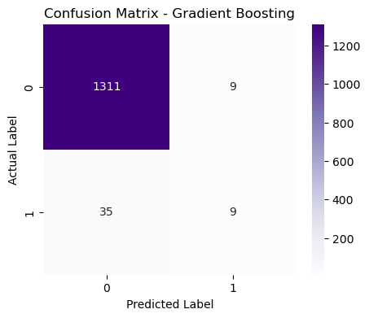

```python
plt.figure(figsize=(5,4))
sns.heatmap(
    cm_gb,
    annot=True,
    fmt='d',
    cmap='Purples'
)
plt.xlabel("Predicted Label")
plt.ylabel("Actual Label")
plt.title("Confusion Matrix - Gradient Boosting")
plt.show()
```

```python
print(classification_report(y_test, y_pred_gb))
```

```
              precision    recall  f1-score   support

           0       0.97      0.99      0.98      1320
           1       0.50      0.20      0.29        44

    accuracy                           0.97      1364
   macro avg       0.74      0.60      0.64      1364
weighted avg       0.96      0.97      0.96      1364
```

```python
gb_importance = pd.DataFrame({
    'Feature': final_features,
    'Importance': gb_model.feature_importances_
}).sort_values(by='Importance', ascending=False)

gb_importance
```

|  | Feature | Importance |
| --- | --- | --- |
| 6 | Persistent EPS in the Last Four Seasons | 0.312150 |
| 5 | Debt ratio % | 0.134938 |
| 4 | Net worth/Assets | 0.118550 |
| 7 | Retained Earnings to Total Assets | 0.081883 |
| 9 | Per Share Net profit before tax (Yuan ¥) | 0.079531 |
| 0 | Net Income to Total Assets | 0.074285 |
| 1 | ROA(A) before interest and % after tax | 0.060082 |
| 8 | Net profit before tax/Paid-in capital | 0.054375 |
| 3 | ROA(C) before interest and depreciation befor... | 0.044807 |
| 2 | ROA(B) before interest and depreciation after... | 0.039398 |

```python
from sklearn.model_selection import GridSearchCV
param_grid = {
    'n_estimators': [100, 150, 200],
    'learning_rate': [0.05, 0.1],
    'max_depth': [3, 4]
}
grid_gb = GridSearchCV(
    GradientBoostingClassifier(random_state=42),
    param_grid,
    cv=5,
    scoring='f1',
    n_jobs=-1
)
grid_gb.fit(X_train_scaled, y_train)
grid_gb.best_params_
```

```
{'learning_rate': 0.1, 'max_depth': 3, 'n_estimators': 200}
```

```python
best_gb = grid_gb.best_estimator_
y_pred_best_gb = best_gb.predict(X_test_scaled)
print(classification_report(y_test, y_pred_best_gb))
```

```
              precision    recall  f1-score   support

           0       0.97      0.99      0.98      1320
           1       0.50      0.20      0.29        44

    accuracy                           0.97      1364
   macro avg       0.74      0.60      0.64      1364
weighted avg       0.96      0.97      0.96      1364
```

### Step 14| XG Boost Model

```python
pip install xgboost
```

```python
from xgboost import XGBClassifier
from sklearn.metrics import (
    accuracy_score,
    precision_score,
    recall_score,
    f1_score,
    confusion_matrix,
    classification_report
)
import matplotlib.pyplot as plt
import seaborn as sns
import pandas as pd
```

```python
xgb_model = XGBClassifier(
    n_estimators=200,
    learning_rate=0.1,
    max_depth=5,
    subsample=0.8,
    colsample_bytree=0.8,
    random_state=42,
    use_label_encoder=False,
    eval_metric='logloss'
)
```

```python
xgb_model.fit(X_train_scaled, y_train)
```

```
XGBClassifier(base_score=None, booster=None, callbacks=None,
              colsample_bylevel=None, colsample_bynode=None,
              colsample_bytree=0.8, device=None, early_stopping_rounds=None,
              enable_categorical=False, eval_metric='logloss',
              feature_types=None, feature_weights=None, gamma=None,
              grow_policy=None, importance_type=None,
              interaction_constraints=None, learning_rate=0.1, max_bin=None,
              max_cat_threshold=None, max_cat_to_onehot=None,
              max_delta_step=None, max_depth=5, max_leaves=None,
              min_child_weight=None, missing=nan, monotone_constraints=None,
              multi_strategy=None, n_estimators=200, n_jobs=None,
              num_parallel_tree=None, ...)
```

```python
y_pred_xgb = xgb_model.predict(X_test_scaled)
```

```python
accuracy_xgb = accuracy_score(y_test, y_pred_xgb)
precision_xgb = precision_score(y_test, y_pred_xgb)
recall_xgb = recall_score(y_test, y_pred_xgb)
f1_xgb = f1_score(y_test, y_pred_xgb)

print("XGBoost Performance")
print("Accuracy :", accuracy_xgb)
print("Precision:", precision_xgb)
print("Recall   :", recall_xgb)
print("F1 Score :", f1_xgb)
```

```
XGBoost Performance
Accuracy : 0.9626099706744868
Precision: 0.3333333333333333
Recall   : 0.1590909090909091
F1 Score : 0.2153846153846154
```

```python
cm_xgb = confusion_matrix(y_test, y_pred_xgb)
cm_xgb
```

```
array([[1306,   14],
       [  37,    7]])
```

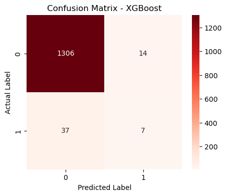

```python
plt.figure(figsize=(5,4))
sns.heatmap(
    cm_xgb,
    annot=True,
    fmt='d',
    cmap='Reds'
)
plt.xlabel("Predicted Label")
plt.ylabel("Actual Label")
plt.title("Confusion Matrix - XGBoost")
plt.show()
```

```python
print(classification_report(y_test, y_pred_xgb))
```

```
              precision    recall  f1-score   support

           0       0.97      0.99      0.98      1320
           1       0.33      0.16      0.22        44

    accuracy                           0.96      1364
   macro avg       0.65      0.57      0.60      1364
weighted avg       0.95      0.96      0.96      1364
```

```python
xgb_importance = pd.DataFrame({
    'Feature': final_features,
    'Importance': xgb_model.feature_importances_
}).sort_values(by='Importance', ascending=False)

xgb_importance
```

|  | Feature | Importance |
| --- | --- | --- |
| 6 | Persistent EPS in the Last Four Seasons | 0.262575 |
| 4 | Net worth/Assets | 0.123397 |
| 5 | Debt ratio % | 0.092657 |
| 0 | Net Income to Total Assets | 0.092530 |
| 8 | Net profit before tax/Paid-in capital | 0.083752 |
| 7 | Retained Earnings to Total Assets | 0.078266 |
| 9 | Per Share Net profit before tax (Yuan ¥) | 0.073673 |
| 1 | ROA(A) before interest and % after tax | 0.072002 |
| 2 | ROA(B) before interest and depreciation after... | 0.062011 |
| 3 | ROA(C) before interest and depreciation befor... | 0.059138 |

```python
from sklearn.model_selection import GridSearchCV

param_grid = {
    'n_estimators': [100, 200],
    'max_depth': [3, 5],
    'learning_rate': [0.05, 0.1],
    'subsample': [0.8, 1.0],
    'colsample_bytree': [0.8, 1.0]
}

grid_xgb = GridSearchCV(
    XGBClassifier(
        random_state=42,
        eval_metric='logloss'
    ),
    param_grid,
    cv=5,
    scoring='f1',
    n_jobs=-1
)

grid_xgb.fit(X_train_scaled, y_train)

grid_xgb.best_params_
```

```
{'colsample_bytree': 1.0,
 'learning_rate': 0.1,
 'max_depth': 5,
 'n_estimators': 200,
 'subsample': 0.8}
```

```python
best_xgb = grid_xgb.best_estimator_
y_pred_best_xgb = best_xgb.predict(X_test_scaled)
print(classification_report(y_test, y_pred_best_xgb))
```

```
              precision    recall  f1-score   support

           0       0.97      0.99      0.98      1320
           1       0.50      0.23      0.31        44

    accuracy                           0.97      1364
   macro avg       0.74      0.61      0.65      1364
weighted avg       0.96      0.97      0.96      1364
```

```python
from xgboost import XGBClassifier
```

```python
xgb_model = XGBClassifier(
    objective="binary:logistic",
    n_estimators=200,
    learning_rate=0.1,
    max_depth=5,
    subsample=0.8,
    colsample_bytree=0.8,
    eval_metric="logloss",
    random_state=42
)
```

```python
xgb_model.fit(X_train, y_train)
```

```
XGBClassifier(base_score=None, booster=None, callbacks=None,
              colsample_bylevel=None, colsample_bynode=None,
              colsample_bytree=0.8, device=None, early_stopping_rounds=None,
              enable_categorical=False, eval_metric='logloss',
              feature_types=None, feature_weights=None, gamma=None,
              grow_policy=None, importance_type=None,
              interaction_constraints=None, learning_rate=0.1, max_bin=None,
              max_cat_threshold=None, max_cat_to_onehot=None,
              max_delta_step=None, max_depth=5, max_leaves=None,
              min_child_weight=None, missing=nan, monotone_constraints=None,
              multi_strategy=None, n_estimators=200, n_jobs=None,
              num_parallel_tree=None, ...)
```

```python
xgb_model.score(X_test, y_test)
```

```
0.9626099706744868
```

### Step 15| Model Evaluation , Comparison & Conclusion

# Model Comparison Table

```python
import pandas as pd

model_comparison = pd.DataFrame({
    "Model": [
        "Logistic Regression",
        "Decision Tree",
        "Random Forest",
        "Gradient Boosting",
        "XGBoost"
    ],
    "Accuracy": [
        accuracy,
        accuracy_dt,
        accuracy_score(y_test, y_pred_rf),
        accuracy_gb,
        accuracy_xgb
    ],
    "Precision": [
        precision,
        precision_dt,
        precision_score(y_test, y_pred_rf),
        precision_gb,
        precision_xgb
    ],
    "Recall": [
        recall,
        recall_dt,
        recall_score(y_test, y_pred_rf),
        recall_gb,
        recall_xgb
    ],
    "F1-Score": [
        f1,
        f1_dt,
        f1_score(y_test, y_pred_rf),
        f1_gb,
        f1_xgb
    ]
})

model_comparison
```

|  | Model | Accuracy | Precision | Recall | F1-Score |
| --- | --- | --- | --- | --- | --- |
| 0 | Logistic Regression | 0.969208 | 0.571429 | 0.181818 | 0.275862 |
| 1 | Decision Tree | 0.963343 | 0.431818 | 0.431818 | 0.431818 |
| 2 | Random Forest | 0.969941 | 0.600000 | 0.204545 | 0.305085 |
| 3 | Gradient Boosting | 0.967742 | 0.500000 | 0.204545 | 0.290323 |
| 4 | XGBoost | 0.962610 | 0.333333 | 0.159091 | 0.215385 |

```python
model_comparison_sorted = model_comparison.sort_values(
    by="F1-Score",
    ascending=False
)

model_comparison_sorted
```

|  | Model | Accuracy | Precision | Recall | F1-Score |
| --- | --- | --- | --- | --- | --- |
| 1 | Decision Tree | 0.963343 | 0.431818 | 0.431818 | 0.431818 |
| 2 | Random Forest | 0.969941 | 0.600000 | 0.204545 | 0.305085 |
| 3 | Gradient Boosting | 0.967742 | 0.500000 | 0.204545 | 0.290323 |
| 0 | Logistic Regression | 0.969208 | 0.571429 | 0.181818 | 0.275862 |
| 4 | XGBoost | 0.962610 | 0.333333 | 0.159091 | 0.215385 |

```python
best_model = model_comparison_sorted.iloc[0]
best_model
```

```
Model        Decision Tree
Accuracy          0.963343
Precision         0.431818
Recall            0.431818
F1-Score          0.431818
Name: 1, dtype: object
```

[figure not shown]

```python
import matplotlib.pyplot as plt

model_comparison.set_index("Model")[["Accuracy", "Precision", "Recall", "F1-Score"]].plot(
    kind="bar",
    figsize=(12,6)
)

plt.title("Model Performance Comparison")
plt.ylabel("Score")
plt.xticks(rotation=45)
plt.legend(loc="lower right")
plt.show()
```

### Final Model Selection

# Voting Classifier

```python
from sklearn.ensemble import VotingClassifier
from sklearn.metrics import (
    accuracy_score,
    precision_score,
    recall_score,
    f1_score,
    confusion_matrix,
    classification_report
)
import matplotlib.pyplot as plt
import seaborn as sns
```

```python
lr = LogisticRegression(max_iter=1000, random_state=42)
rf = RandomForestClassifier(n_estimators=200, random_state=42, n_jobs=-1)
gb = GradientBoostingClassifier(n_estimators=150, learning_rate=0.1, random_state=42)
```

```python
voting_model = VotingClassifier(
    estimators=[
        ('lr', lr),
        ('rf', rf),
        ('gb', gb)
    ],
    voting='hard'
)
```

```python
voting_model.fit(X_train_scaled, y_train)
```

```
VotingClassifier(estimators=[('lr',
                              LogisticRegression(max_iter=1000,
                                                 random_state=42)),
                             ('rf',
                              RandomForestClassifier(n_estimators=200,
                                                     n_jobs=-1,
                                                     random_state=42)),
                             ('gb',
                              GradientBoostingClassifier(n_estimators=150,
                                                         random_state=42))])
```

```python
y_pred_voting = voting_model.predict(X_test_scaled)
```

```python
accuracy_v = accuracy_score(y_test, y_pred_voting)
precision_v = precision_score(y_test, y_pred_voting)
recall_v = recall_score(y_test, y_pred_voting)
f1_v = f1_score(y_test, y_pred_voting)

print("Voting Classifier Performance")
print("Accuracy :", accuracy_v)
print("Precision:", precision_v)
print("Recall   :", recall_v)
print("F1 Score :", f1_v)
```

```
Voting Classifier Performance
Accuracy : 0.9714076246334311
Precision: 0.6666666666666666
Recall   : 0.22727272727272727
F1 Score : 0.3389830508474576
```

```python
cm_voting = confusion_matrix(y_test, y_pred_voting)
cm_voting
```

```
array([[1315,    5],
       [  34,   10]])
```

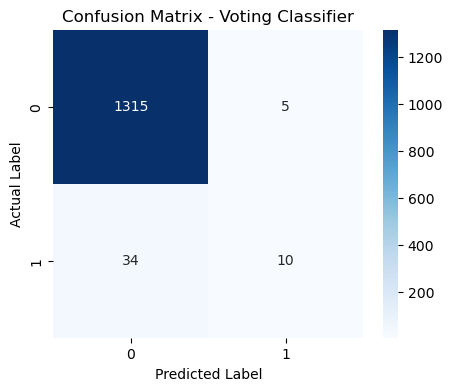

```python
plt.figure(figsize=(5,4))
sns.heatmap(
    cm_voting,
    annot=True,
    fmt='d',
    cmap='Blues'
)
plt.xlabel("Predicted Label")
plt.ylabel("Actual Label")
plt.title("Confusion Matrix - Voting Classifier")
plt.show()
```

```python
print(classification_report(y_test, y_pred_voting))
```

```
              precision    recall  f1-score   support

           0       0.97      1.00      0.99      1320
           1       0.67      0.23      0.34        44

    accuracy                           0.97      1364
   macro avg       0.82      0.61      0.66      1364
weighted avg       0.96      0.97      0.96      1364
```

```python
model_comparison.loc[len(model_comparison)] = [
    "Voting Classifier",
    accuracy_v,
    precision_v,
    recall_v,
    f1_v
]

model_comparison.sort_values(by="F1-Score", ascending=False)
```

|  | Model | Accuracy | Precision | Recall | F1-Score |
| --- | --- | --- | --- | --- | --- |
| 1 | Decision Tree | 0.963343 | 0.431818 | 0.431818 | 0.431818 |
| 5 | Voting Classifier | 0.971408 | 0.666667 | 0.227273 | 0.338983 |
| 2 | Random Forest | 0.969941 | 0.600000 | 0.204545 | 0.305085 |
| 3 | Gradient Boosting | 0.967742 | 0.500000 | 0.204545 | 0.290323 |
| 0 | Logistic Regression | 0.969208 | 0.571429 | 0.181818 | 0.275862 |
| 4 | XGBoost | 0.962610 | 0.333333 | 0.159091 | 0.215385 |

### Voting Classifier (Ensemble Model)